# Pulmonic stenosis survival stats

## Get area plot for posterior distributons of beta parameters

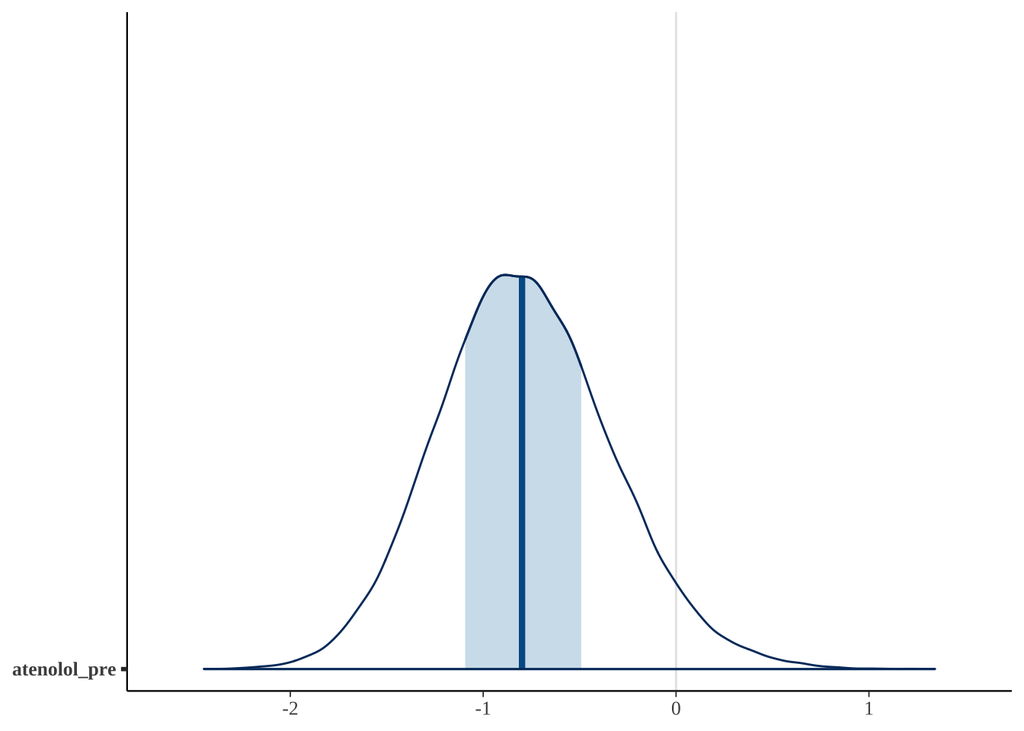

```r
mcmc_areas(posterior_mod_aten_pre,
  pars = "atenolol_pre")
```

## Calculate hazard ratios for atenololpre

### a. get posterior draws

```r
aten_pre_hr <- exp(draws[,2]) # 2nd column is draws for atenololpre
```

### b. Summarise hazard ratios for atenololpre

```r
median(aten_pre_hr)
```

```
## [1] 0.4498753
```

```r
hpdi_aten_pre_hr <- HPDI(aten_pre_hr, prob = c(0.89, 0.97))
hpdi_aten_pre_hr
```

```
##     |0.97     |0.89     0.89|     0.97|
## 0.1312806 0.1760450 0.8237430 1.1185229
```

### c. Plot posterior distribution for hazard ratio of atenololpre

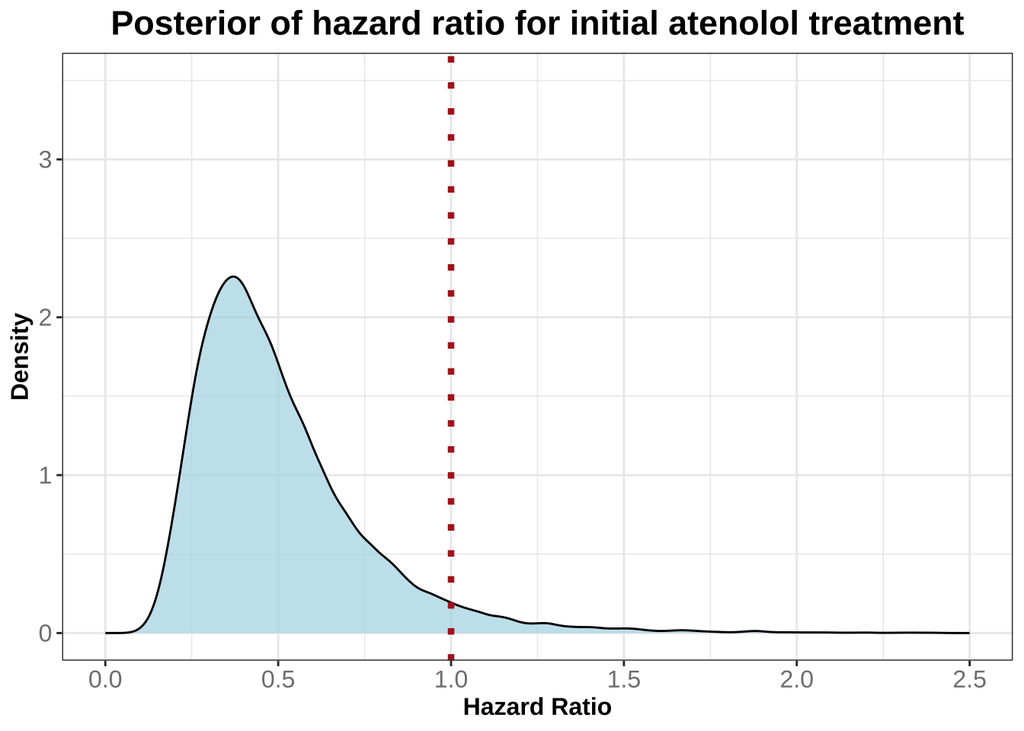

```r
ggplot(data.frame(aten_pre_hr), aes(x = aten_pre_hr)) +
  geom_density(fill = "lightblue", alpha = 0.7) +
  labs(title = "Posterior of hazard ratio for initial atenolol treatment",
       x = "Hazard Ratio",
       y = "Density") +

  theme_bw() +
           theme(axis.title.y = element_text(size=12, face="bold"),
               axis.title.x = element_text(size=12, face="bold"),
               title = element_text(size=14, face="bold"),
               plot.title = element_text(hjust = 0.5),
               axis.text.x = element_text(color = "grey50", size = 12),
               axis.text.y = element_text(color = "grey50",size = 12)) +
  geom_vline(xintercept = 1, linetype="dotted",
                color = "firebrick", linewidth = 1.5) +
  ylim(0, 3.5) +
  xlim(0, 2.5)
```

### 2. Check performance of prior probability

```r
mod_aten_pre_prior_only <- update(mod_aten_pre, prior_PD = TRUE)
```

[output not shown]

[output not shown]

[output not shown]

[output not shown]

[output not shown]

[output not shown]

[output not shown]

[output not shown]

[output not shown]

[output not shown]

### 3. Check prosterior vs prior for beta variable

#### a. extract draws for posterior and prior

```r
# extract draws
post_draws  <- as.matrix(mod_aten_pre)
prior_draws <- as.matrix(mod_aten_pre_prior_only)
```

#### b. plot marginal distributions for posterior and prior

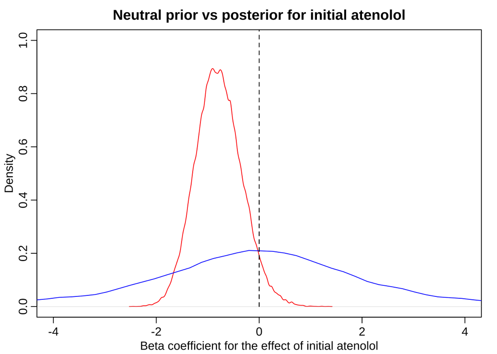

```r
# Compare marginal distributions
dens(post_draws[, "atenolol_pre"], show.zero = TRUE, col = "red", main = "Neutral prior vs posterior for initial atenolol", xlab = "Beta coefficient for the effect of initial atenolol", xlim = c(-4, 4), ylim = c(0, 1.0))
dens(prior_draws[, "atenolol_pre"], add=TRUE, col = "blue", show.zero = TRUE)
```

#### c. compute prior tail probability of posterior mean

If this probability is very small (e.g. < 0.05), the posterior lies in a region the prior considered implausible.

```r
beta_hat <- mean(post_draws[, "atenolol_pre"])

mean(abs(prior_draws[, "atenolol_pre"] - beta_hat) <
       abs(prior_draws[, "atenolol_pre"] - mean(prior_draws[, "atenolol_pre"])))
```

```
## [1] 0.419875
```

### 4. Sensitivity analyses to assess robustness of results to choice of prior

To determine whether the substantive conclusions depend upon the exact prior choice.

```r
priors_bin <- list(
  weak = student_t(df = 3, location = 0, scale = 3.5, autoscale = FALSE),
  moderate = student_t(df = 3, location = 0, scale = 1.75, autoscale = FALSE),
  strong = student_t(df = 3, location = 0, scale = 0.825, autoscale = FALSE)
)
```

#### b. refit model with different priors and compare results

```r
fits <- lapply(priors_bin, function(p) {
  stan_surv(formula = Surv(tstart, tstop, status) ~ atenolol_pre
                      + s_tapse
                      + (1| centre),
            basehaz = "ms",
            data = df,
            prior_intercept = normal(location = 0, scale = 20, autoscale = FALSE),
            prior = p,
            prior_covariance =  decov(regularization = 2, concentration = 1, shape = 1, scale = 1),
            iter    = 2000,
            chains = 4,
            cores = 4,
            adapt_delta = 0.99999,  # Often helpful for complex models
            control = list(max_treedepth = 20),
            init = 0.1,
            seed = 666
            )
})
```

[output not shown]

[output not shown]

[output not shown]

[output not shown]

[output not shown]

[output not shown]

[output not shown]

[output not shown]

[output not shown]

[output not shown]

[output not shown]

[output not shown]

[output not shown]

[output not shown]

[output not shown]

[output not shown]

[output not shown]

[output not shown]

[output not shown]

[output not shown]

[output not shown]

[output not shown]

[output not shown]

[output not shown]

[output not shown]

[output not shown]

[output not shown]

[output not shown]

[output not shown]

#### c. compare posterior intervals for hazard ratios across different priors

```r
# calculate median hazard ratio across different priors
HR_med_sens <- sapply(fits, function(f) {
  posterior::as_draws_df(f) |>
    as.data.frame() |>
    summarise(
      median = exp(quantile(atenolol_pre, probs = 0.5))
    )
})
HR_med <- c(HR_med_sens[[1]], HR_med_sens[[2]], HR_med_sens[[3]])


# calculate 89% credible interval for hazard ratio across different priors
HR_sens <- sapply(fits, function(f) {
  exp(posterior_interval(f, pars = "atenolol_pre", prob = 0.89))
})

# combine median and credible intervals into a summary table
HR_sens_summary <- rbind(HR_med, HR_sens)
row.names(HR_sens_summary) <- c("Median", "Lower", "Upper")

# transpose the table for better readability
HR_sens_summary
```

```
##             weak  moderate    strong
## Median 0.4369261 0.4478872 0.5124041
## Lower  0.2107201 0.2235014 0.2626726
## Upper  0.9511373 0.9154616 1.0358935
```

## Make model predictions and plot for mod_aten_pre

### 1. Create new data where atenololpre differs

```r
nd <- data.frame(centre = rep("p", 2),
                 atenolol_pre = c(0, 1),
                 s_tapse = rep(0, 2)
                 )
head(nd)
```

```
##   centre atenolol_pre s_tapse
## 1      p            0       0
## 2      p            1       0
```

### 2. Make posterior predictions from new data

```r
ps <- posterior_survfit(mod_aten_pre,
  newdata = nd,
  times = 0,
  extrapolate = TRUE) |>
  suppressWarnings()
head(ps)
```

```
## stan_surv predictions
##  num. individuals: 2
##  prediction type:  event free probability
##  standardised?:    no
##  conditional?:     no
##
##   id cond_time     time median  ci_lb  ci_ub
## 1  1        NA   0.0000 1.0000 1.0000 1.0000
## 2  1        NA  32.7172 0.9370 0.8223 0.9844
## 3  1        NA  65.4343 0.8884 0.7061 0.9709
## 4  1        NA  98.1515 0.8556 0.6396 0.9578
## 5  1        NA 130.8687 0.8293 0.5882 0.9494
## 6  1        NA 163.5859 0.8060 0.5405 0.9385
```

### 3. Plot

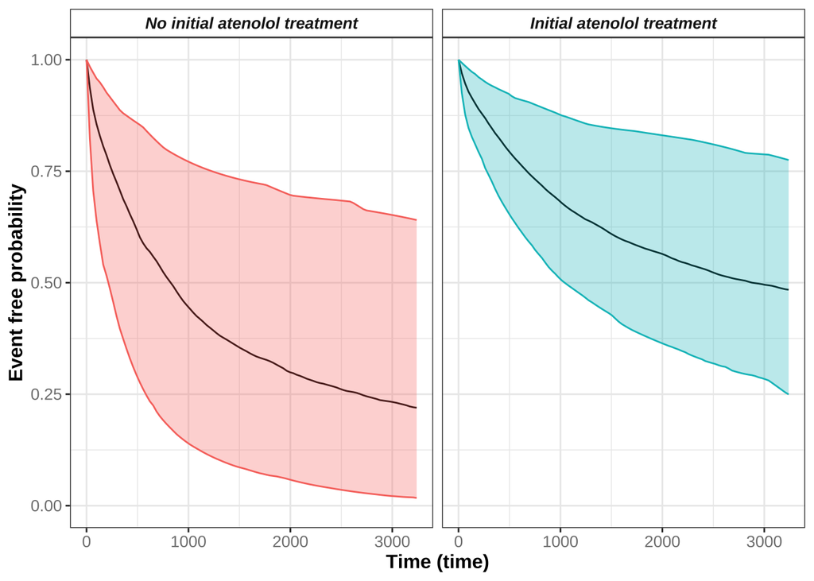

```r
panel_labels <- c('1' = "No initial atenolol treatment", '2' = "Initial atenolol treatment")
pps <- plot(ps) +
  aes(colour = factor(id), fill = factor(id)) +
  theme(legend.position = "none") +
  facet_wrap(~ id, labeller = labeller(id = panel_labels)) +
           theme(axis.title.y = element_text(size=12, face="bold"),
               axis.title.x = element_text(size=12, face="bold"),
               title = element_text(size=12, face="bold"),
               plot.title = element_text(hjust = 0.5),
               axis.text.x = element_text(color = "grey50", size = 10),
               axis.text.y = element_text(color = "grey50",size = 10)) +
            theme(strip.text.x = element_text(size = 10, face = "bold.italic"),
                   strip.background = element_rect(fill="white")
        )

print(pps)
```

## Check PH assumption visually

### make predictions of both the hazard and log hazard

```r
ph <- suppressWarnings( posterior_survfit(mod_aten_pre, newdata = nd, type = "haz") )
pl <- suppressWarnings( posterior_survfit(mod_aten_pre, newdata = nd, type = "loghaz") )
```

#### create plots

```r
pph <- plot(ph) +
  coord_cartesian(ylim = c(0.0, 0.005)) +
  facet_wrap(~ id, labeller = labeller(id = panel_labels))
```

```
## ℹ Adding new coordinate system, which will replace the existing one.
```

```r
ppl <- plot(pl) +
  facet_wrap(~ id, labeller = labeller(id = panel_labels))
```

#### combine plots in grid and plot

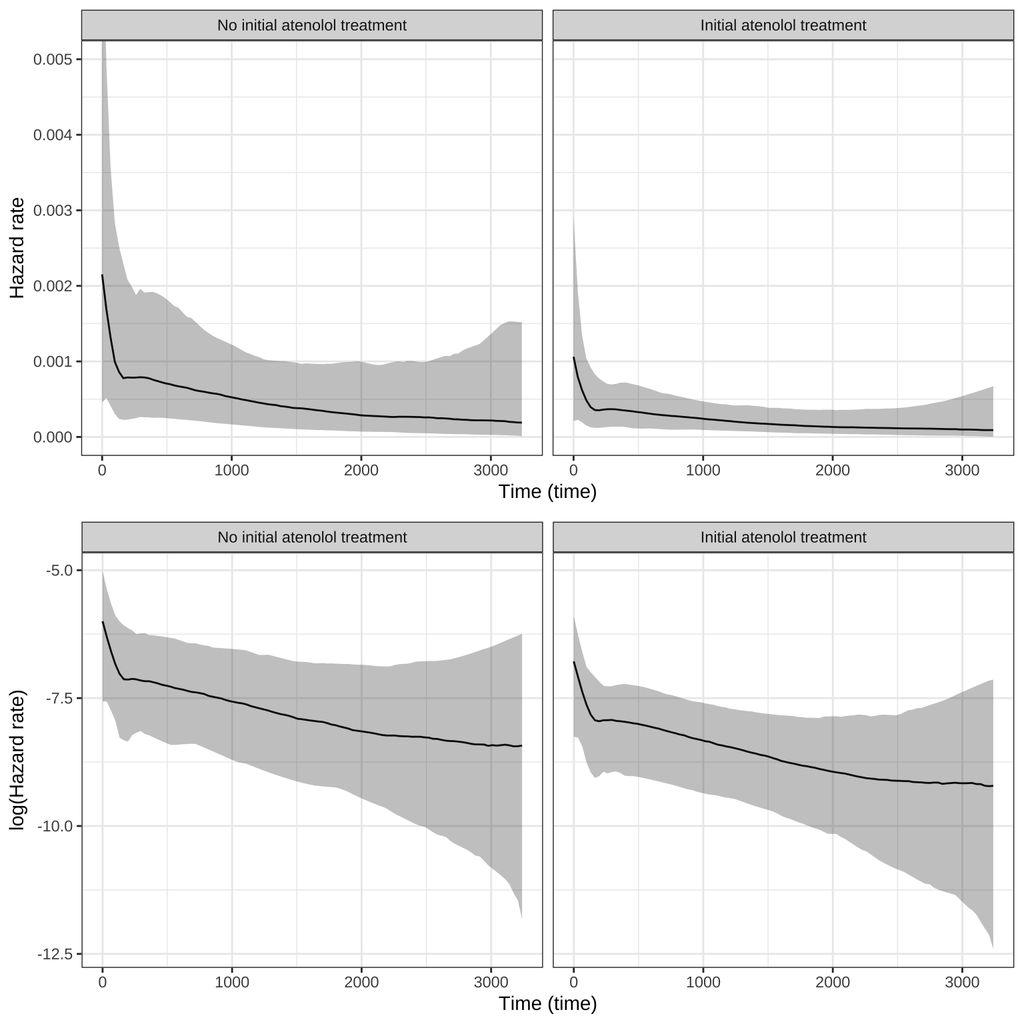

```r
plot_grid(pph, ppl
        , ncol = 1)
```

# XIIb. Bayesian multi-level survival analysis for effect of atenolol_post with random intercept for centre and control set

## Set prior for beta variables

**Set a neutral, weakly-regularising prior…**

student_t(df = 3, location = 0, scale = 2.0)

```r
prior_beta_aten_post <- student_t(df = 3, location = c(0, 0, 0), scale = c(2.0, 1.5, 1.5), autoscale = c(FALSE, FALSE, FALSE))
```

Based on the DAG, use the following adjustment variables: atenolol_pre, intervention (yes) and referral centre.

## Fit model

NB use status … rstanarm requires the dead animals to be classified as 1, whilst censored are 0.

```r
mod_aten_post <- stan_surv(formula = Surv(tstart, tstop, status) ~ atenolol_post
                      + atenolol_pre
                      + surgery
                      + (1| centre),
  data = df,
  basehaz = "ms",
  prior_intercept = normal(location = 0, scale = 15, autoscale = FALSE),
  prior = prior_beta_aten_post,
  prior_covariance =  decov(regularization = 2, concentration = 1, shape = 1, scale = 1),
  iter    = 12000,
  warmup = 4000,
  chains = 4,
  cores = 4,
  adapt_delta = 0.99999,  # Often helpful for complex models
  control = list(max_treedepth = 20),
  init = 0.1,
  seed = 666)
```

[output not shown]

[output not shown]

[output not shown]

[output not shown]

[output not shown]

[output not shown]

[output not shown]

[output not shown]

[output not shown]

[output not shown]

## Summarise priors from model

```r
prior_summary(mod_aten_post)
```

```
## Priors for model 'mod_aten_post'
## ------
## Intercept
##  ~ normal(location = 0, scale = 15)
##
## Coefficients
##  ~ student_t(df = [3,3,3], location = [0,0,0], scale = [2.0,1.5,1.5])
##
## Auxiliary (M-spline-coefficients)
##  ~ dirichlet(concentration = [1,1,1,...])
##
## Covariance
##  ~ decov(reg. = 2, conc. = 1, shape = 1, scale = 1)
## ------
## See help('prior_summary.stanreg') for more details
```

## Model summary

```r
summary(mod_aten_post)
```

```
##
## Model Info:
##
##  function:        stan_surv
##  baseline hazard: M-splines on hazard scale
##  formula:         Surv(tstart, tstop, status) ~ atenolol_post + atenolol_pre +
##     surgery + (1 | centre)
##  algorithm:       sampling
##  sample:          32000 (posterior sample size)
##  priors:          see help('prior_summary')
##  observations:    198
##  events:          41 (20.7%)
##  right censored:  157 (79.3%)
##  delayed entry:   yes
##
## Estimates:
##                                         mean   sd   10%   50%   90%
## (Intercept)                            0.9    0.7  0.0   0.9   1.8
## atenolol_post                         -1.3    0.5 -2.0  -1.4  -0.7
## atenolol_pre                          -1.1    0.4 -1.6  -1.1  -0.6
## surgery1                               0.9    0.5  0.2   0.9   1.5
## m-splines-coef1                        0.1    0.0  0.0   0.1   0.1
## m-splines-coef2                        0.1    0.1  0.0   0.1   0.2
## m-splines-coef3                        0.4    0.1  0.2   0.4   0.6
## m-splines-coef4                        0.2    0.1  0.0   0.2   0.4
## m-splines-coef5                        0.1    0.1  0.0   0.1   0.2
## m-splines-coef6                        0.1    0.1  0.0   0.1   0.3
## b[(Intercept) centre:p]               -0.6    0.7 -1.4  -0.5   0.1
## b[(Intercept) centre:sath]             0.4    0.6 -0.2   0.4   1.2
## b[(Intercept) centre:willows]          0.2    0.6 -0.4   0.1   0.9
## Sigma[centre:(Intercept),(Intercept)]  1.0    1.9  0.1   0.5   2.3
##
## MCMC diagnostics
##                                       mcse Rhat n_eff
## (Intercept)                           0.0  1.0  11142
## atenolol_post                         0.0  1.0  17671
## atenolol_pre                          0.0  1.0  25717
## surgery1                              0.0  1.0  19484
## m-splines-coef1                       0.0  1.0  34007
## m-splines-coef2                       0.0  1.0  24990
## m-splines-coef3                       0.0  1.0  25918
## m-splines-coef4                       0.0  1.0  23301
## m-splines-coef5                       0.0  1.0  35592
## m-splines-coef6                       0.0  1.0  38369
## b[(Intercept) centre:p]               0.0  1.0  10070
## b[(Intercept) centre:sath]            0.0  1.0   9046
## b[(Intercept) centre:willows]         0.0  1.0   9366
## Sigma[centre:(Intercept),(Intercept)] 0.0  1.0  12789
## log-posterior                         0.0  1.0   8499
##
## For each parameter, mcse is Monte Carlo standard error, n_eff is a crude measure of effective sample size, and Rhat is the potential scale reduction factor on split chains (at convergence Rhat=1).
```

## Model short summary

```r
print(mod_aten_post, digits = 3)
```

```
## stan_surv
##  baseline hazard: M-splines on hazard scale
##  formula:         Surv(tstart, tstop, status) ~ atenolol_post + atenolol_pre +
##     surgery + (1 | centre)
##  observations:    198
##  events:          41 (20.7%)
##  right censored:  157 (79.3%)
##  delayed entry:   yes
## ------
##                 Median MAD_SD exp(Median)
## (Intercept)      0.900  0.638     NA
## atenolol_post   -1.356  0.502  0.258
## atenolol_pre    -1.126  0.375  0.324
## surgery1         0.893  0.505  2.442
## m-splines-coef1  0.075  0.038     NA
## m-splines-coef2  0.075  0.051     NA
## m-splines-coef3  0.414  0.152     NA
## m-splines-coef4  0.175  0.147     NA
## m-splines-coef5  0.083  0.080     NA
## m-splines-coef6  0.089  0.088     NA
##
## Error terms:
##  Groups Name        Std.Dev.
##  centre (Intercept) 1.011
## Num. levels: centre 3
##
## ------
## * For help interpreting the printed output see ?print.stanreg
## * For info on the priors used see ?prior_summary.stanreg
```

## Plot Baseline hazard of model

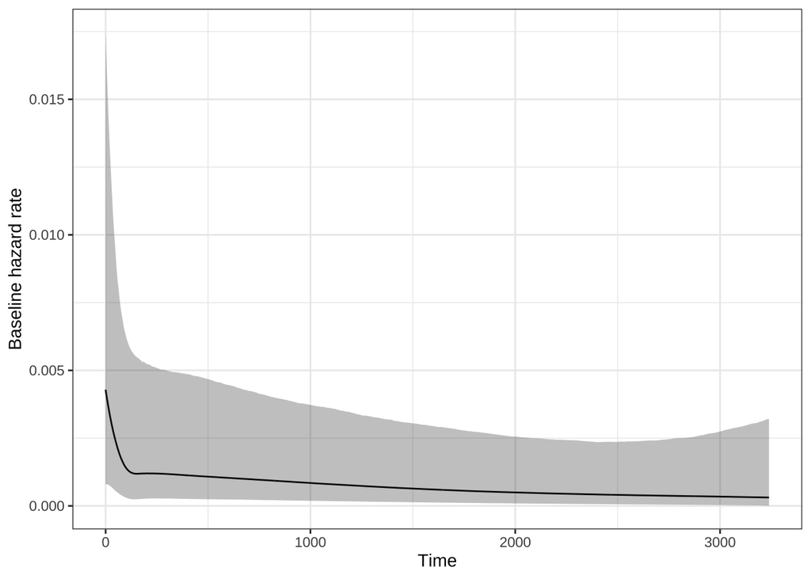

```r
plot(mod_aten_post)
```

## Plots of model convergences

## Get results

```r
posterior_mod_aten_post <- as.array(mod_aten_post)
```

### a. Check trace plots for model

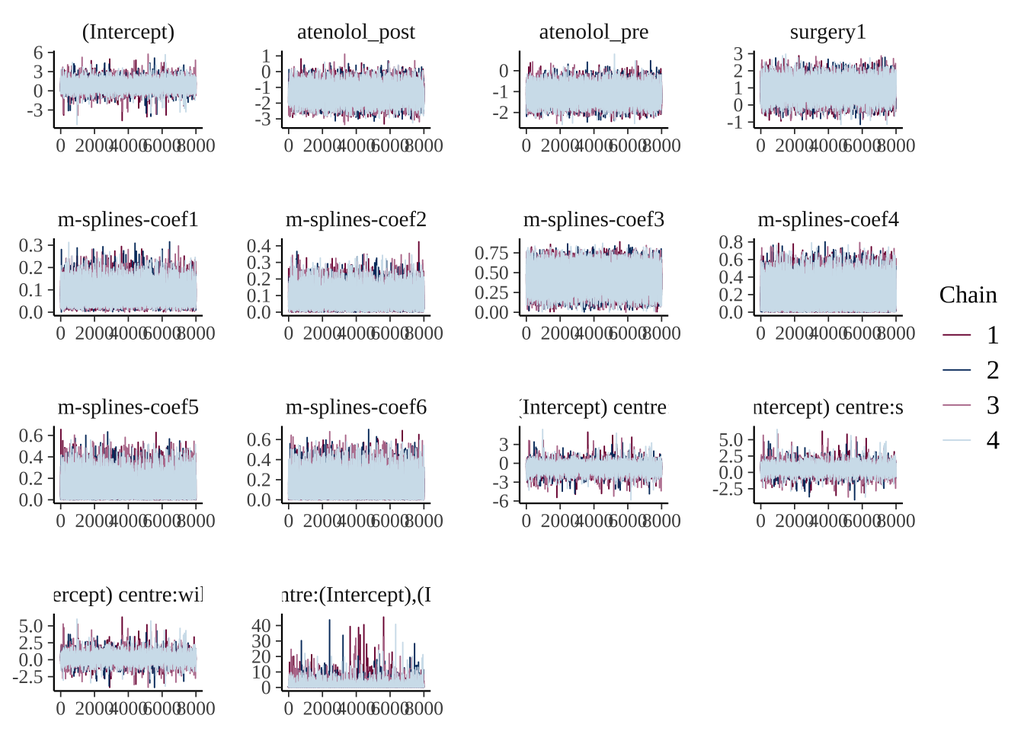

```r
color_scheme_set("mix-blue-pink")
mcmc_trace(posterior_mod_aten_post)
```

### b. Trace rank plot

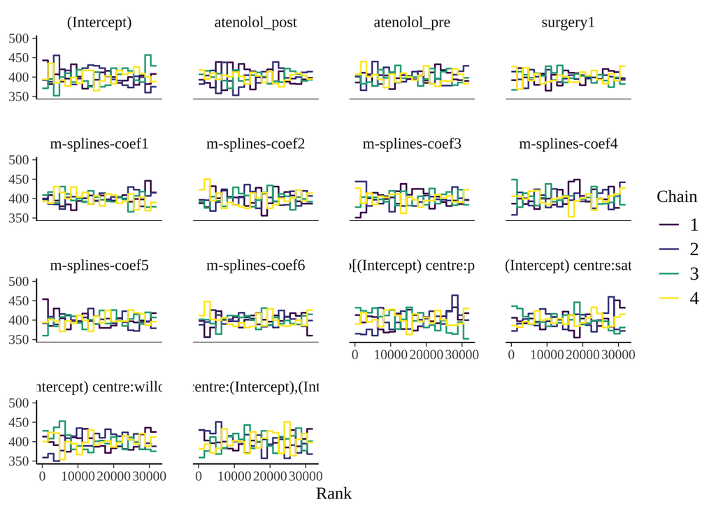

```r
color_scheme_set("viridis")
mcmc_rank_overlay(posterior_mod_aten_post) +
  ylim(350,500)
```

### c. get dens overlay plot for chains

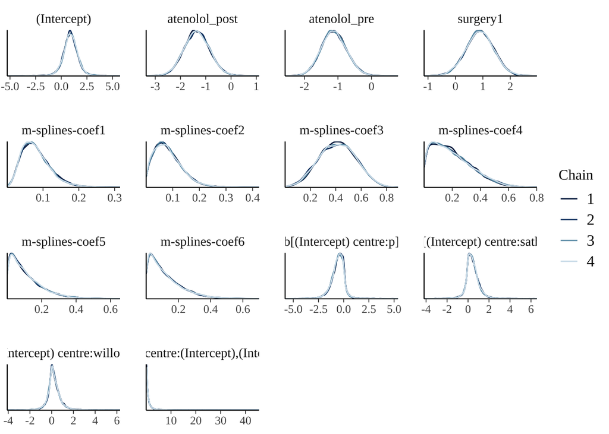

```r
color_scheme_set("blue")
mcmc_dens_overlay(posterior_mod_aten_post)
```

## Summaries of coefficients

### a. HPDI for the different beta parameters

```r
draws <- as.matrix(mod_aten_post)
median(draws[,2]) # draws for atenolol_post
```

```
## [1] -1.356472
```

```r
HPDI(draws[,2], 0.97) # draws for atenolol_post
```

```
##      |0.97      0.97|
## -2.4457515 -0.2354069
```

```r
HPDI(draws[,2], 0.89) # draws for atenolol_post
```

```
##      |0.89      0.89|
## -2.1613203 -0.5540217
```

### b. Hypothesis tests on beta parameters

#### i. probability that effect is positive

```r
mean(draws[,2] > 0) # draws for atenolol_post
```

```
## [1] 0.005
```

#### ii. probability that effect is negative

```r
mean(draws[,2] < 0) # draws for atenolol_post
```

```
## [1] 0.995
```

### c. Plot posterior distribution for beta coefficient of s_aten_post

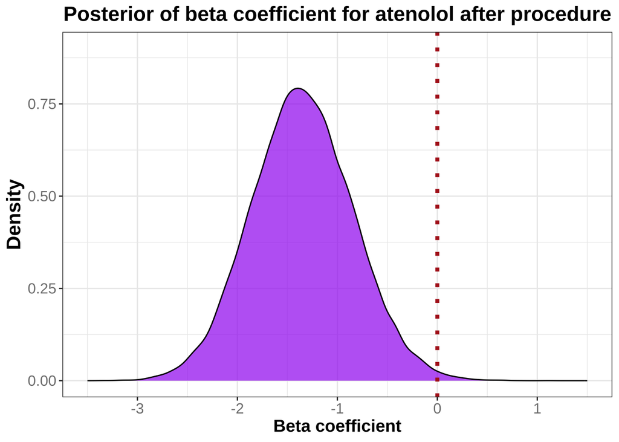

```r
s_aten_post <- draws[,2] # 2nd column is draws for s_aten_post

ggplot(data.frame(s_aten_post), aes(x = s_aten_post)) +
  geom_density(fill = "purple", alpha = 0.7) +
  labs(title = "Posterior of beta coefficient for atenolol after procedure",
       x = "Beta coefficient",
       y = "Density") +
  theme_bw() +
           theme(axis.title.y = element_text(size=16, face="bold"),
               axis.title.x = element_text(size=14, face="bold"),
               title = element_text(size=14, face="bold"),
               plot.title = element_text(hjust = 0.5),
               axis.text.x = element_text(color = "grey50", size = 12),
               axis.text.y = element_text(color = "grey50",size = 12)) +
  geom_vline(xintercept = 0, linetype="dotted",
                color = "firebrick", linewidth = 1.5) +
                xlim(-3.5, 1.5) +
                ylim(0, 0.9)
```

## Get HDI for coefficients

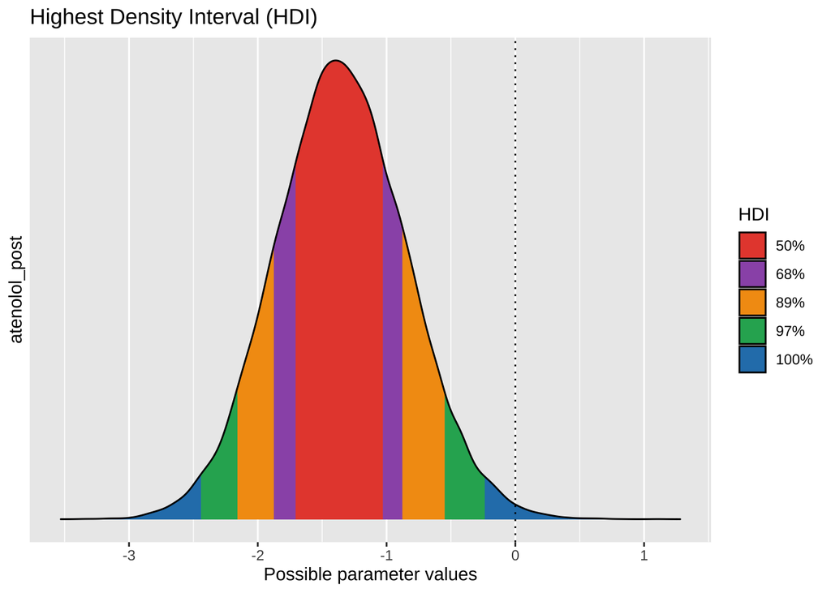

```r
hdi <- bayestestR::hdi(mod_aten_post, ci = c(0.50, 0.68, 0.89, 0.97), parameters = "atenolol_post")
plot(hdi)
```

## Get density plots for posterior distributons of beta parameters

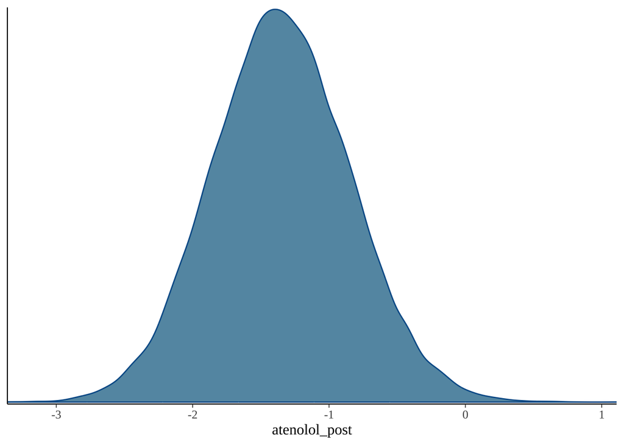

```r
mcmc_dens(posterior_mod_aten_post,
  pars = c("atenolol_post"))
```

## Get area plot for posterior distributons of beta parameters

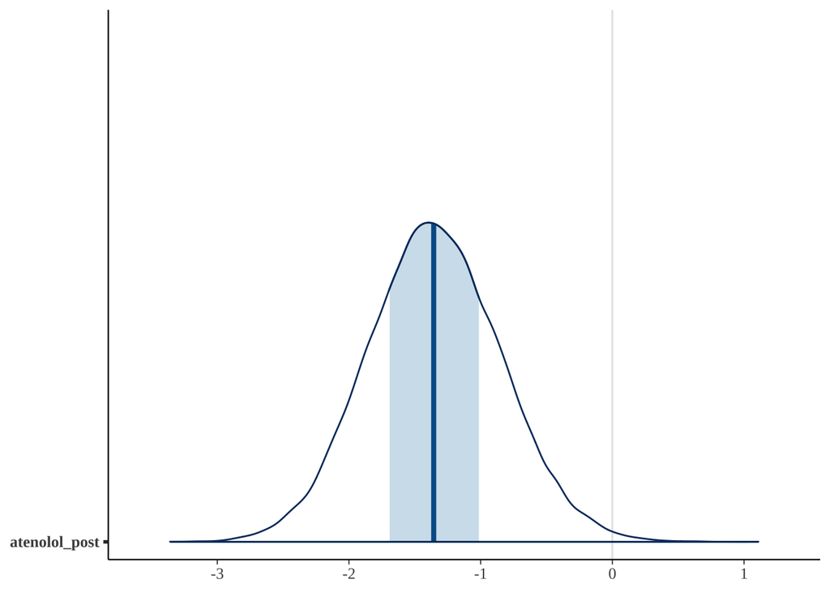

```r
mcmc_areas(posterior_mod_aten_post,
  pars = "atenolol_post")
```

## Calculate hazard ratios for atenololpost

### a. get posterior draws

```r
aten_post_hr <- exp(draws[,2]) # 2nd column is draws for atenololpost
```

### b. Summarise hazard ratios for atenolol_post

```r
median(aten_post_hr)
```

```
## [1] 0.2575679
```

```r
hpdi_aten_post_hr <- HPDI(aten_post_hr, prob = c(0.89, 0.97))
hpdi_aten_post_hr
```

```
##      |0.97      |0.89      0.89|      0.97|
## 0.05766284 0.08390138 0.49857801 0.68520195
```

### c. Plot posterior distribution for hazard ratio of atenololpost

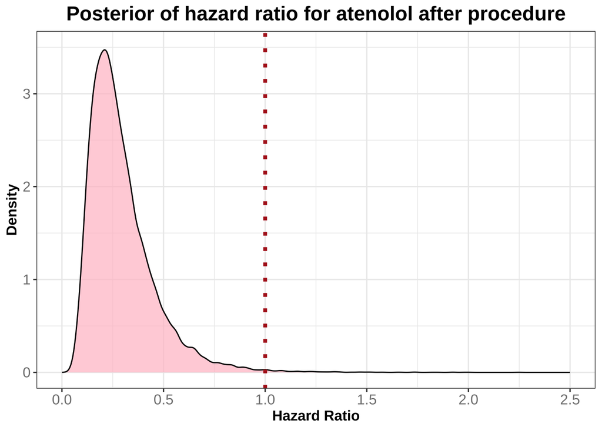

```r
ggplot(data.frame(aten_post_hr), aes(x = aten_post_hr)) +
  geom_density(fill = "pink", alpha = 0.7) +
  labs(title = "Posterior of hazard ratio for atenolol after procedure",
       x = "Hazard Ratio",
       y = "Density") +

  theme_bw() +
           theme(axis.title.y = element_text(size=12, face="bold"),
               axis.title.x = element_text(size=12, face="bold"),
               title = element_text(size=14, face="bold"),
               plot.title = element_text(hjust = 0.5),
               axis.text.x = element_text(color = "grey50", size = 12),
               axis.text.y = element_text(color = "grey50",size = 12)) +
  geom_vline(xintercept = 1, linetype="dotted",
                color = "firebrick", linewidth = 1.5) +
  ylim(0, 3.5) +
  xlim(0, 2.5)
```

### 2. Check performance of prior probability

```r
mod_aten_post_prior_only <- update(mod_aten_post, prior_PD = TRUE)
```

[output not shown]

[output not shown]

[output not shown]

[output not shown]

[output not shown]

[output not shown]

[output not shown]

[output not shown]

[output not shown]

[output not shown]

### 3. Check prosterior vs prior for beta variable

#### a. extract draws for posterior and prior

```r
# extract draws
post_draws  <- as.matrix(mod_aten_post)
prior_draws <- as.matrix(mod_aten_post_prior_only)
```

#### b. plot marginal distributions for posterior and prior

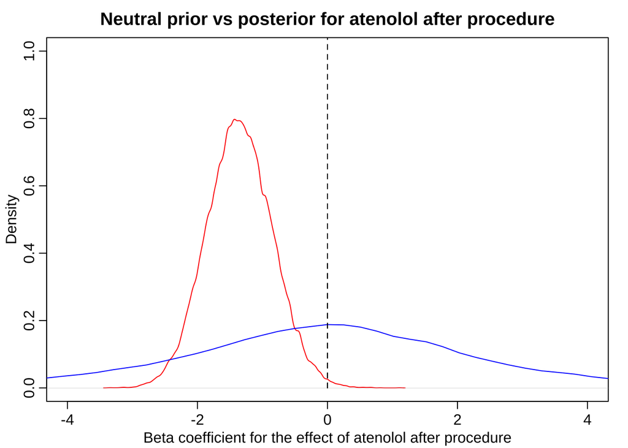

```r
# Compare marginal distributions
dens(post_draws[, "atenolol_post"], show.zero = TRUE, col = "red", main = "Neutral prior vs posterior for atenolol after procedure", xlab = "Beta coefficient for the effect of atenolol after procedure", xlim = c(-4, 4), ylim = c(0, 1.0))
dens(prior_draws[, "atenolol_post"], add=TRUE, col = "blue", show.zero = TRUE)
```

#### c. compute prior tail probability of posterior mean

If this probability is very small (e.g. < 0.05), the posterior lies in a region the prior considered implausible.

```r
beta_hat <- mean(post_draws[, "atenolol_post"])

mean(abs(prior_draws[, "atenolol_post"] - beta_hat) <
       abs(prior_draws[, "atenolol_post"] - mean(prior_draws[, "atenolol_post"])))
```

```
## [1] 0.377
```

### 4. Sensitivity analyses to assess robustness of results to choice of prior

To determine whether the substantive conclusions depend upon the exact prior choice.

```r
priors_bin <- list(
  weak = student_t(df = 3, location = 0, scale = 4, autoscale = FALSE),
  moderate = student_t(df = 3, location = 0, scale = 2, autoscale = FALSE),
  strong = student_t(df = 3, location = 0, scale = 1, autoscale = FALSE)
)
```

#### b. refit model with different priors and compare results

```r
fits <- lapply(priors_bin, function(p) {
  stan_surv(formula = Surv(tstart, tstop, status) ~ atenolol_post
                      + surgery
                      + atenolol_pre
                      + (1| centre),
            basehaz = "ms",
            data = df,
            prior_intercept = normal(location = 0, scale = 15, autoscale = FALSE),
            prior = p,
            prior_covariance =  decov(regularization = 2, concentration = 1, shape = 1, scale = 1),
            iter    = 2000,
            chains = 4,
            cores = 4,
            adapt_delta = 0.99999,  # Often helpful for complex models
            control = list(max_treedepth = 20),
            init = 0.1,
            seed = 666
            )
})
```

[output not shown]

[output not shown]

[output not shown]

[output not shown]

[output not shown]

[output not shown]

[output not shown]

[output not shown]

[output not shown]

[output not shown]

[output not shown]

[output not shown]

[output not shown]

[output not shown]

[output not shown]

[output not shown]

[output not shown]

[output not shown]

[output not shown]

[output not shown]

[output not shown]

[output not shown]

[output not shown]

[output not shown]

[output not shown]

[output not shown]

[output not shown]

[output not shown]

[output not shown]

[output not shown]

#### c. compare posterior intervals for hazard ratios across different priors

```r
# calculate median hazard ratio across different priors
HR_med_sens <- sapply(fits, function(f) {
  posterior::as_draws_df(f) |>
    as.data.frame() |>
    summarise(
      median = exp(quantile(atenolol_post, probs = 0.5))
    )
})
HR_med <- c(HR_med_sens[[1]], HR_med_sens[[2]], HR_med_sens[[3]])


# calculate 89% credible interval for hazard ratio across different priors
HR_sens <- sapply(fits, function(f) {
  exp(posterior_interval(f, pars = "atenolol_post", prob = 0.89))
})

# combine median and credible intervals into a summary table
HR_sens_summary <- rbind(HR_med, HR_sens)
row.names(HR_sens_summary) <- c("Median", "Lower", "Upper")

# transpose the table for better readability
HR_sens_summary
```

```
##             weak  moderate    strong
## Median 0.2293080 0.2536920 0.3163436
## Lower  0.1027926 0.1157756 0.1437247
## Upper  0.5380558 0.5883096 0.7160991
```

## Make model predictions and plot for mod_aten_post

### 1. Create new data where atenololpost differs

```r
nd <- data.frame(centre = rep("p", 2),
                 atenolol_post = c(0, 1),
                 surgery = rep(1, 2),
                 atenolol_pre = rep(1, 2)
                 )
head(nd)
```

```
##   centre atenolol_post surgery atenolol_pre
## 1      p             0       1            1
## 2      p             1       1            1
```

### 2. Make posterior predictions from new data

```r
ps <- posterior_survfit(mod_aten_post,
  newdata = nd,
  times = 0,
  extrapolate = TRUE) |>
  suppressWarnings()
head(ps)
```

```
## stan_surv predictions
##  num. individuals: 2
##  prediction type:  event free probability
##  standardised?:    no
##  conditional?:     no
##
##   id cond_time     time median  ci_lb  ci_ub
## 1  1        NA   0.0000 1.0000 1.0000 1.0000
## 2  1        NA  32.7172 0.9506 0.8373 0.9893
## 3  1        NA  65.4343 0.9201 0.7539 0.9811
## 4  1        NA  98.1515 0.8982 0.7036 0.9727
## 5  1        NA 130.8687 0.8808 0.6707 0.9657
## 6  1        NA 163.5859 0.8682 0.6384 0.9595
```

### 3. Plot

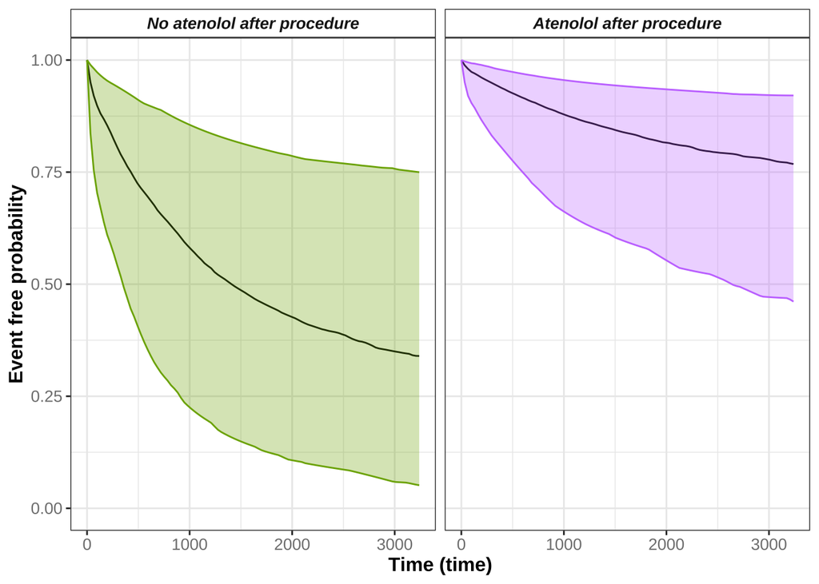

```r
panel_labels <- c('1' = "No atenolol after procedure", '2' = "Atenolol after procedure")
pps <- plot(ps) +
  aes(colour = factor(id), fill = factor(id)) +
  theme(legend.position = "none") +
  facet_wrap(~ id, labeller = labeller(id = panel_labels)) +
           theme(axis.title.y = element_text(size=12, face="bold"),
               axis.title.x = element_text(size=12, face="bold"),
               title = element_text(size=12, face="bold"),
               plot.title = element_text(hjust = 0.5),
               axis.text.x = element_text(color = "grey50", size = 10),
               axis.text.y = element_text(color = "grey50",size = 10)) +
            theme(strip.text.x = element_text(size = 10, face = "bold.italic"),
                   strip.background = element_rect(fill="white")) +
            scale_colour_hue(h.start = 90) +
            scale_fill_hue(h.start = 90)

print(pps)
```

## B. Make model predictions and plot for mod_aten_post - ADVANCED

### 1. Create new data where atenolol differs

```r
nd <- data.frame(centre = rep("p", 4),
                 atenolol_post = c(0, 0, 1, 1),
                 atenolol_pre = c(0, 1, 0, 1),
                 surgery = rep(1, 4)
                 )
head(nd)
```

```
##   centre atenolol_post atenolol_pre surgery
## 1      p             0            0       1
## 2      p             0            1       1
## 3      p             1            0       1
## 4      p             1            1       1
```

### 2. Make posterior predictions from new data

```r
ps <- posterior_survfit(mod_aten_post,
  newdata = nd,
  times = 0,
  extrapolate = TRUE) |>
  suppressWarnings()
head(ps)
```

```
## stan_surv predictions
##  num. individuals: 4
##  prediction type:  event free probability
##  standardised?:    no
##  conditional?:     no
##
##   id cond_time     time median  ci_lb  ci_ub
## 1  1        NA   0.0000 1.0000 1.0000 1.0000
## 2  1        NA  32.7172 0.8609 0.5608 0.9609
## 3  1        NA  65.4343 0.7728 0.4147 0.9226
## 4  1        NA  98.1515 0.7234 0.3601 0.8991
## 5  1        NA 130.8687 0.6786 0.3265 0.8822
## 6  1        NA 163.5859 0.6403 0.2884 0.8651
```

### 3. Plot

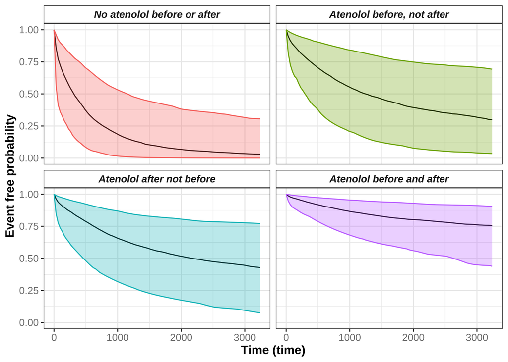

```r
panel_labels <- c('1' = "No atenolol before or after", '2' = "Atenolol before, not after",
                  '3' = "Atenolol after not before", '4' = "Atenolol before and after")
pps <- plot(ps) +
  aes(colour = factor(id), fill = factor(id)) +
  theme(legend.position = "none") +
  facet_wrap(~ id, labeller = labeller(id = panel_labels)) +
           theme(axis.title.y = element_text(size=12, face="bold"),
               axis.title.x = element_text(size=12, face="bold"),
               title = element_text(size=12, face="bold"),
               plot.title = element_text(hjust = 0.5),
               axis.text.x = element_text(color = "grey50", size = 10),
               axis.text.y = element_text(color = "grey50",size = 10)) +
            theme(strip.text.x = element_text(size = 10, face = "bold.italic"),
                   strip.background = element_rect(fill="white")
        )

print(pps)
```

## Check PH assumption visually

### make predictions of both the hazard and log hazard

```r
ph <- suppressWarnings( posterior_survfit(mod_aten_post, newdata = nd, type = "haz") )
pl <- suppressWarnings( posterior_survfit(mod_aten_post, newdata = nd, type = "loghaz") )
```

#### create plots

```r
pph <- plot(ph) +
  coord_cartesian(ylim = c(0.0, 0.005)) +
  facet_wrap(~ id, labeller = labeller(id = panel_labels))
```

```
## ℹ Adding new coordinate system, which will replace the existing one.
```

```r
ppl <- plot(pl) +
  facet_wrap(~ id, labeller = labeller(id = panel_labels))
```

#### combine plots in grid and plot

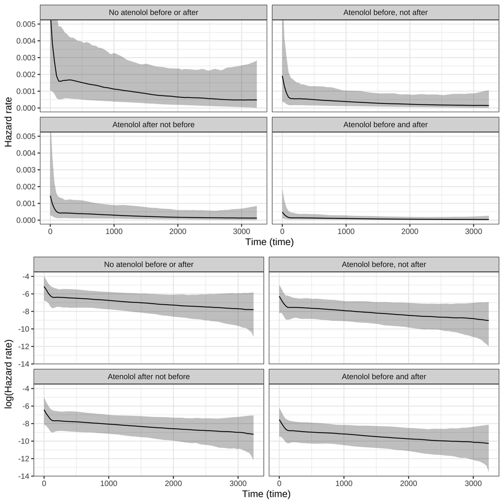

```r
plot_grid(pph, ppl, ncol = 1)
```

# XIII. Bayesian multi-level survival analysis for effect of PROCEDURE TYPE with SEPARATE VARIABLES (balloon / stent) random intercept for centre and control set

## Set prior for beta variables

**Set a neutral, weakly-regularising prior…**

```r
prior_beta_prtyp <- student_t(df = 3, location = 0, scale = 1.5, autoscale = FALSE)
```

Based on the DAG, use the following adjustment variables: concurrent congen, referral centre, stenosis type (and sx yes). NB need to use surgery df to ensure that the analysis is only on dogs that have had surgery.

## Fit model

NB use status … rstanarm requires the dead animals to be classified as 1, whilst censored are 0.

```r
mod_prtyp <- stan_surv(formula = Surv(tstart, tstop, status) ~ balloon * stent
                        + concurrent_congenital
                        + type
                        + (1| centre),
  data = df_surg,
  basehaz = "ms",
  prior_intercept = normal(location = 0, scale = 15, autoscale = FALSE),
  prior = prior_beta_prtyp,
  prior_covariance =  decov(regularization = 2, concentration = 1, shape = 1, scale = 1),
  iter    = 12000,
  warmup = 4000,
  chains = 4,
  cores = 4,
  adapt_delta = 0.999,  # Often helpful for complex models
  seed = 666)
```

[output not shown]

[output not shown]

[output not shown]

[output not shown]

[output not shown]

[output not shown]

[output not shown]

[output not shown]

[output not shown]

[output not shown]

## Summarise priors from model

```r
prior_summary(mod_prtyp)
```

```
## Priors for model 'mod_prtyp'
## ------
## Intercept
##  ~ normal(location = 0, scale = 15)
##
## Coefficients
##  ~ student_t(df = [3,3,3,...], location = [0,0,0,...], scale = [1.5,1.5,1.5,...])
##
## Auxiliary (M-spline-coefficients)
##  ~ dirichlet(concentration = [1,1,1,...])
##
## Covariance
##  ~ decov(reg. = 2, conc. = 1, shape = 1, scale = 1)
## ------
## See help('prior_summary.stanreg') for more details
```

## Model summary

```r
summary(mod_prtyp)
```

```
##
## Model Info:
##
##  function:        stan_surv
##  baseline hazard: M-splines on hazard scale
##  formula:         Surv(tstart, tstop, status) ~ balloon * stent + concurrent_congenital +
##     type + (1 | centre)
##  algorithm:       sampling
##  sample:          32000 (posterior sample size)
##  priors:          see help('prior_summary')
##  observations:    85
##  events:          25 (29.4%)
##  right censored:  60 (70.6%)
##  delayed entry:   yes
##
## Estimates:
##                                         mean   sd   10%   50%   90%
## (Intercept)                           -0.8    1.1 -2.2  -0.8   0.6
## balloon                                0.0    1.0 -1.2   0.0   1.2
## stent                                  0.5    1.0 -0.7   0.5   1.7
## concurrent_congenital1                 0.8    0.4  0.3   0.8   1.4
## typeb                                 -0.9    0.7 -1.8  -0.8   0.0
## typeintermediate                       0.4    0.5 -0.2   0.4   1.0
## balloon:stent                          0.4    1.0 -0.8   0.4   1.7
## m-splines-coef1                        0.1    0.1  0.0   0.1   0.2
## m-splines-coef2                        0.1    0.1  0.0   0.1   0.2
## m-splines-coef3                        0.4    0.2  0.2   0.4   0.6
## m-splines-coef4                        0.2    0.1  0.0   0.1   0.3
## m-splines-coef5                        0.1    0.1  0.0   0.1   0.2
## m-splines-coef6                        0.1    0.1  0.0   0.1   0.3
## b[(Intercept) centre:p]               -0.1    0.4 -0.6   0.0   0.3
## b[(Intercept) centre:sath]             0.0    0.4 -0.4   0.0   0.4
## b[(Intercept) centre:willows]          0.1    0.4 -0.2   0.1   0.6
## Sigma[centre:(Intercept),(Intercept)]  0.4    1.0  0.0   0.1   0.9
##
## MCMC diagnostics
##                                       mcse Rhat n_eff
## (Intercept)                           0.0  1.0  16190
## balloon                               0.0  1.0  16882
## stent                                 0.0  1.0  17047
## concurrent_congenital1                0.0  1.0  30972
## typeb                                 0.0  1.0  28447
## typeintermediate                      0.0  1.0  27215
## balloon:stent                         0.0  1.0  18066
## m-splines-coef1                       0.0  1.0  38732
## m-splines-coef2                       0.0  1.0  28090
## m-splines-coef3                       0.0  1.0  28005
## m-splines-coef4                       0.0  1.0  25882
## m-splines-coef5                       0.0  1.0  39112
## m-splines-coef6                       0.0  1.0  37550
## b[(Intercept) centre:p]               0.0  1.0  18337
## b[(Intercept) centre:sath]            0.0  1.0  14561
## b[(Intercept) centre:willows]         0.0  1.0  12741
## Sigma[centre:(Intercept),(Intercept)] 0.0  1.0  16100
## log-posterior                         0.0  1.0  11596
##
## For each parameter, mcse is Monte Carlo standard error, n_eff is a crude measure of effective sample size, and Rhat is the potential scale reduction factor on split chains (at convergence Rhat=1).
```

## Model short summary

```r
print(mod_prtyp, digits = 3)
```

```
## stan_surv
##  baseline hazard: M-splines on hazard scale
##  formula:         Surv(tstart, tstop, status) ~ balloon * stent + concurrent_congenital +
##     type + (1 | centre)
##  observations:    85
##  events:          25 (29.4%)
##  right censored:  60 (70.6%)
##  delayed entry:   yes
## ------
##                        Median MAD_SD exp(Median)
## (Intercept)            -0.797  1.074     NA
## balloon                -0.009  0.932  0.991
## stent                   0.478  0.919  1.612
## concurrent_congenital1  0.826  0.402  2.285
## typeb                  -0.829  0.720  0.437
## typeintermediate        0.372  0.453  1.450
## balloon:stent           0.440  0.978  1.552
## m-splines-coef1         0.091  0.060     NA
## m-splines-coef2         0.101  0.071     NA
## m-splines-coef3         0.410  0.157     NA
## m-splines-coef4         0.131  0.122     NA
## m-splines-coef5         0.076  0.076     NA
## m-splines-coef6         0.088  0.086     NA
##
## Error terms:
##  Groups Name        Std.Dev.
##  centre (Intercept) 0.6154
## Num. levels: centre 3
##
## ------
## * For help interpreting the printed output see ?print.stanreg
## * For info on the priors used see ?prior_summary.stanreg
```

## Plot Baseline hazard of model

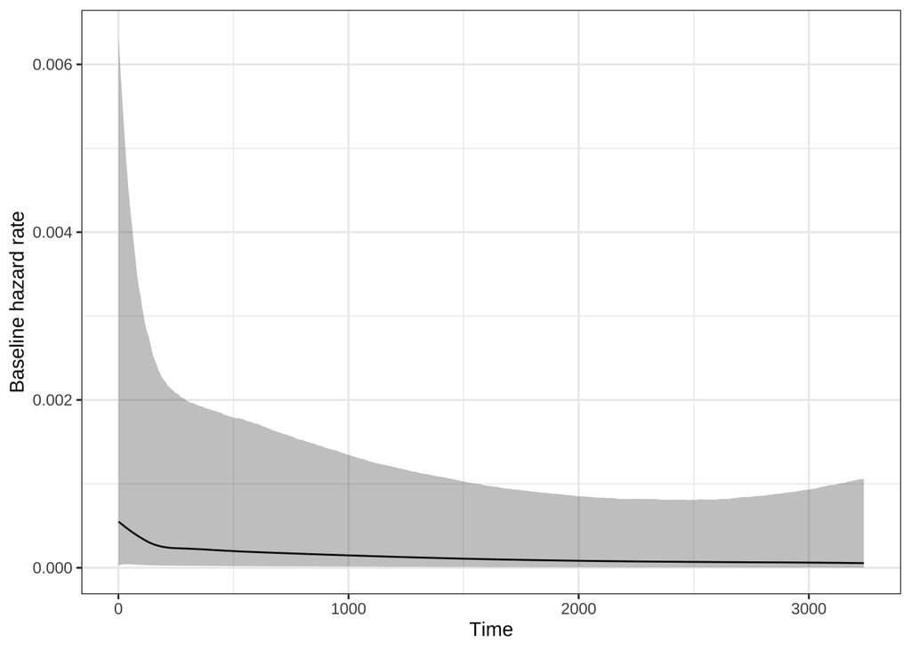

```r
plot(mod_prtyp)
```

## Plots of model convergences

## Get results

```r
posterior_mod_prtyp <- as.array(mod_prtyp)
```

### a. Check trace plots for model

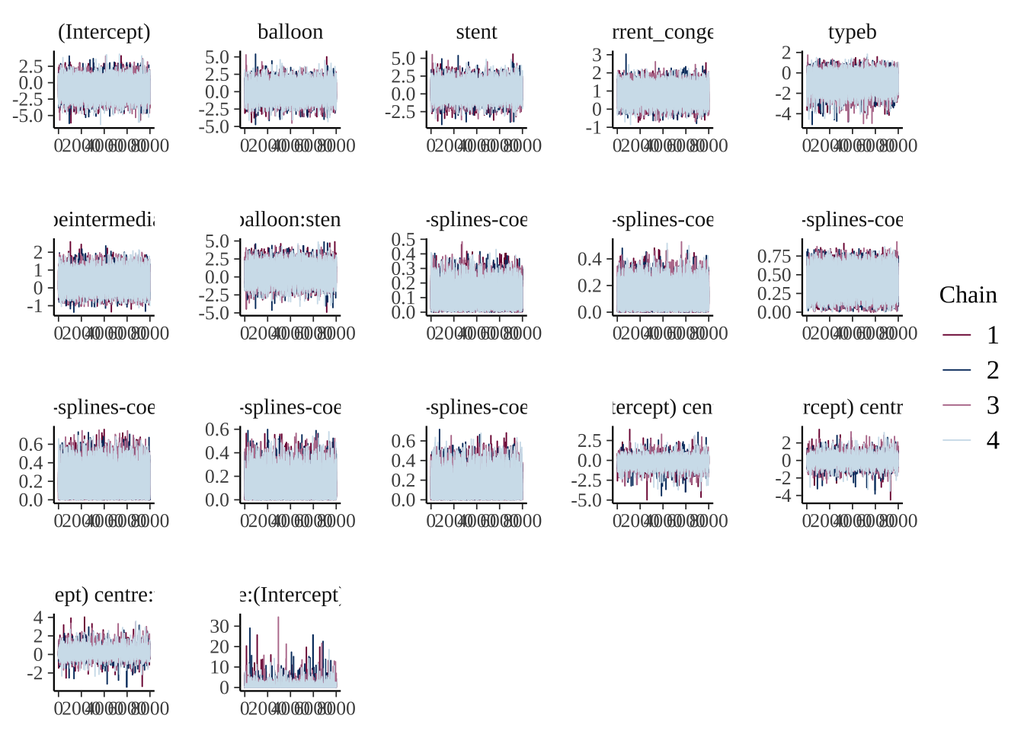

```r
color_scheme_set("mix-blue-pink")
mcmc_trace(posterior_mod_prtyp)
```

### b. Trace rank plot

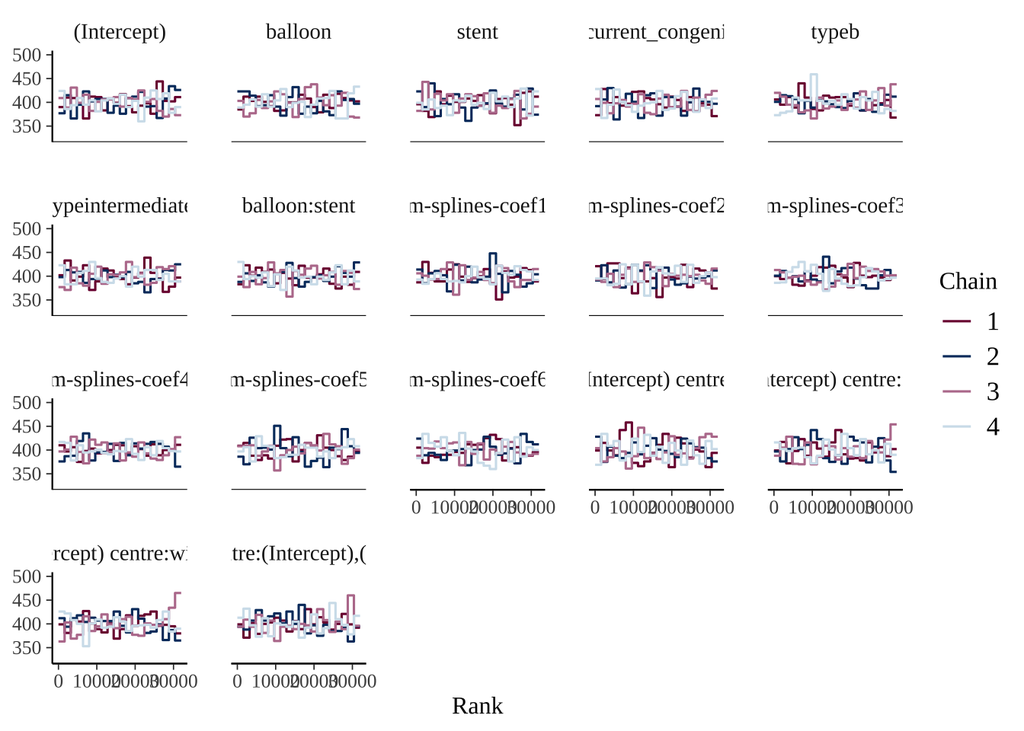

```r
color_scheme_set("mix-blue-pink")
mcmc_rank_overlay(posterior_mod_prtyp) +
  ylim(325, 500)
```

### c. get dens overlay plot for chains

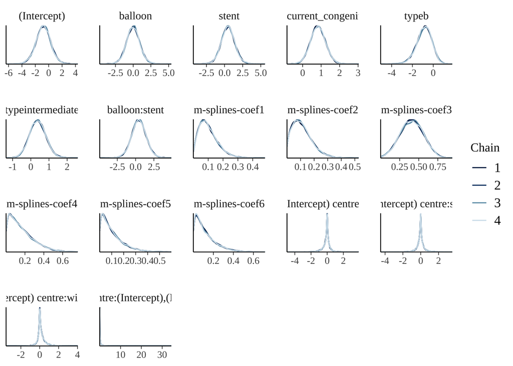

```r
color_scheme_set("blue")
mcmc_dens_overlay(posterior_mod_prtyp)
```

## Summaries of coefficients

### a. HPDI for the different beta parameters

#### i. balloon

```r
draws <- as.matrix(mod_prtyp)
median(draws[,2]) # draws for balloon
```

```
## [1] -0.008692921
```

```r
HPDI(draws[,2], 0.97) # raws for balloon
```

```
##     |0.97     0.97|
## -2.225338  2.123297
```

```r
HPDI(draws[,2], 0.89) # draws for balloon
```

```
##     |0.89     0.89|
## -1.554720  1.497985
```

#### ii. stent

```r
draws <- as.matrix(mod_prtyp)
median(draws[,3]) # draws for stent
```

```
## [1] 0.4775539
```

```r
HPDI(draws[,3], 0.97) # draws for stent
```

```
##     |0.97     0.97|
## -1.640050  2.629521
```

```r
HPDI(draws[,3], 0.89) # draws for stent
```

```
##     |0.89     0.89|
## -1.079834  1.945856
```

#### iii. both

```r
draws <- as.matrix(mod_prtyp)
median(draws[,7]) # draws for balloon:stent
```

```
## [1] 0.4398265
```

```r
HPDI(draws[,7], 0.97) # draws for balloon:stent
```

```
##     |0.97     0.97|
## -1.836113  2.695761
```

```r
HPDI(draws[,7], 0.89) # draws for balloon:stent
```

```
##     |0.89     0.89|
## -1.159645  2.057284
```

### b. Hypothesis tests on beta parameters

```r
mean(draws[,2] < 0)
```

```
## [1] 0.504
```

```r
mean(draws[,3] < 0)
```

```
## [1] 0.3029375
```

```r
mean(draws[,7] < 0)
```

```
## [1] 0.3265
```

#### iv. probability that beta coefficient for balloon and stent is less than stent (better survival)

```r
mean(draws[,7] < draws[,3])
```

```
## [1] 0.5073437
```

### c. Plot posterior distribution for beta coefficient of prtyp

#### i. balloon

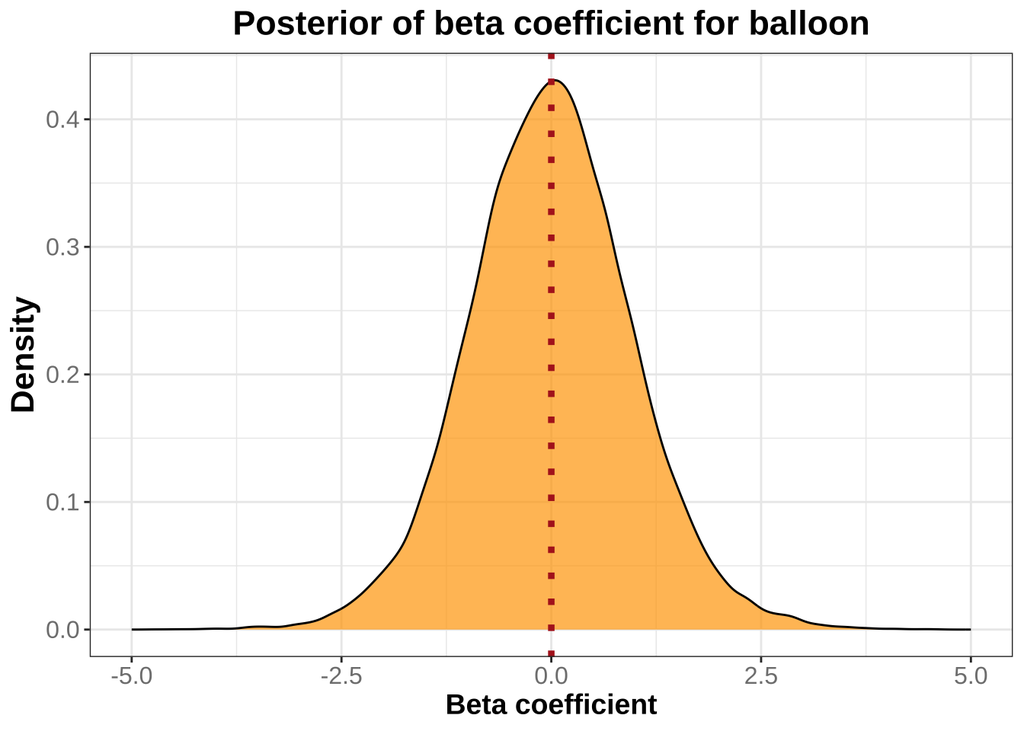

```r
aten_prtyp_b <- draws[,2] # 2nd column is draws for balloon

ggplot(data.frame(aten_prtyp_b), aes(x = aten_prtyp_b)) +
  geom_density(fill = "orange", alpha = 0.7) +
  labs(title = "Posterior of beta coefficient for balloon",
       x = "Beta coefficient",
       y = "Density") +
  theme_bw() +
           theme(axis.title.y = element_text(size=16, face="bold"),
               axis.title.x = element_text(size=14, face="bold"),
               title = element_text(size=14, face="bold"),
               plot.title = element_text(hjust = 0.5),
               axis.text.x = element_text(color = "grey50", size = 12),
               axis.text.y = element_text(color = "grey50",size = 12)) +
  geom_vline(xintercept = 0, linetype="dotted",
                color = "firebrick", linewidth = 1.5) +
  xlim(-5, 5)
```

#### ii. stent

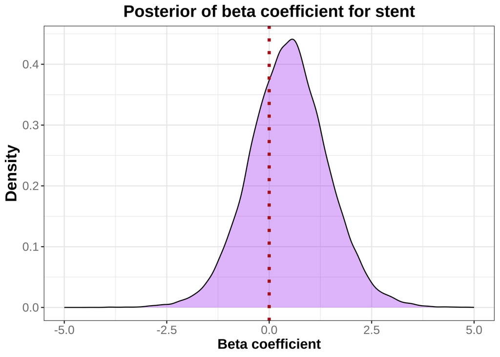

```r
aten_prtyp_st <- draws[,3] # 2nd column is draws for stent

ggplot(data.frame(aten_prtyp_st), aes(x = aten_prtyp_st)) +
  geom_density(fill = "purple", alpha = 0.3) +
  labs(title = "Posterior of beta coefficient for stent",
       x = "Beta coefficient",
       y = "Density") +
  theme_bw() +
           theme(axis.title.y = element_text(size=16, face="bold"),
               axis.title.x = element_text(size=14, face="bold"),
               title = element_text(size=14, face="bold"),
               plot.title = element_text(hjust = 0.5),
               axis.text.x = element_text(color = "grey50", size = 12),
               axis.text.y = element_text(color = "grey50",size = 12)) +
  geom_vline(xintercept = 0, linetype="dotted",
                color = "firebrick", linewidth = 1.5) +
  xlim(-5, 5)
```

#### iii. balloon and stent

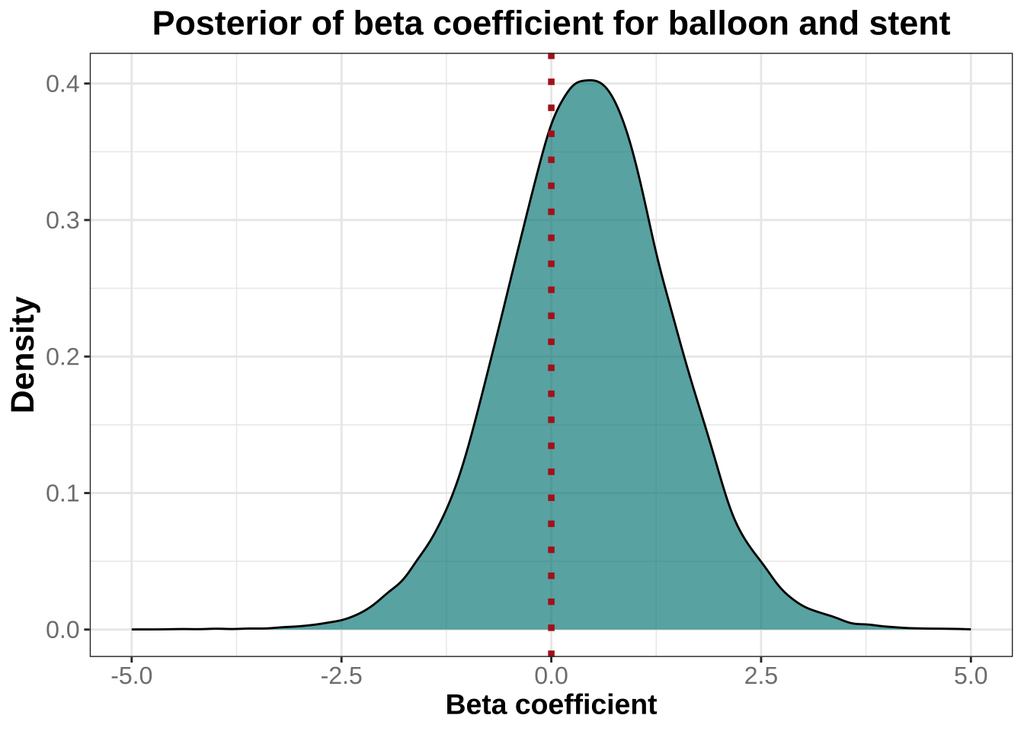

```r
aten_prtyp_bs <- draws[,7] # 2nd column is draws for balloon and stent

ggplot(data.frame(aten_prtyp_bs), aes(x = aten_prtyp_bs)) +
  geom_density(fill = "cyan4", alpha = 0.7) +
  labs(title = "Posterior of beta coefficient for balloon and stent",
       x = "Beta coefficient",
       y = "Density") +
  theme_bw() +
           theme(axis.title.y = element_text(size=16, face="bold"),
               axis.title.x = element_text(size=14, face="bold"),
               title = element_text(size=14, face="bold"),
               plot.title = element_text(hjust = 0.5),
               axis.text.x = element_text(color = "grey50", size = 12),
               axis.text.y = element_text(color = "grey50",size = 12)) +
  geom_vline(xintercept = 0, linetype="dotted",
                color = "firebrick", linewidth = 1.5) +
  xlim(-5, 5)
```

## Get HDI for coefficients

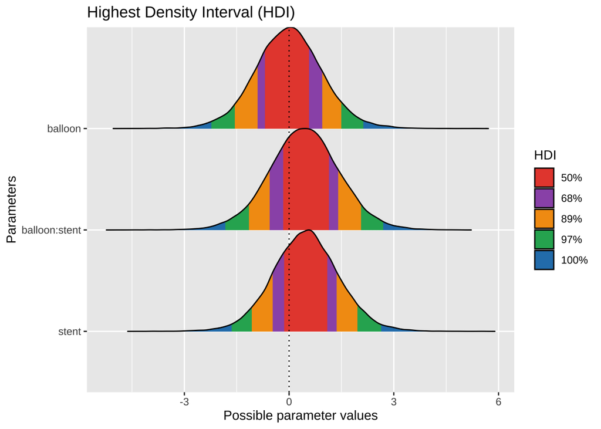

```r
hdi <- bayestestR::hdi(mod_prtyp, ci = c(0.50, 0.68, 0.89, 0.97),
                       parameters = c("balloon", "stent", "balloon:stent"))
plot(hdi)
```

## Get density plots for posterior distributons of beta parameters

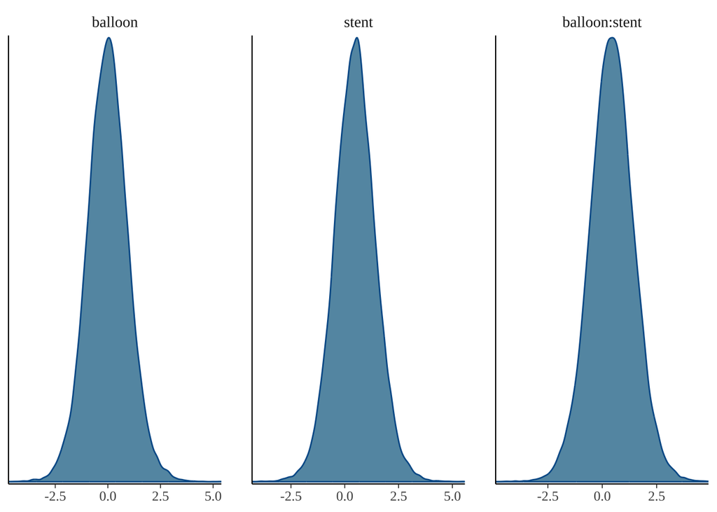

```r
mcmc_dens(posterior_mod_prtyp,
  pars = c("balloon", "stent", "balloon:stent"))
```

## Get area plot for posterior distributons of beta parameters

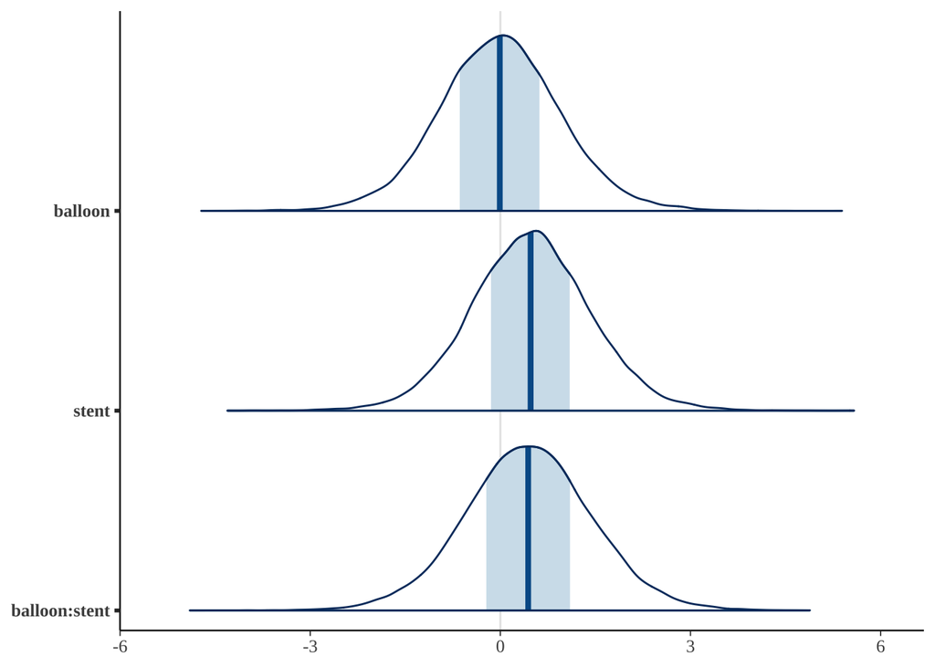

```r
mcmc_areas(posterior_mod_prtyp,
  pars = c("balloon", "stent", "balloon:stent"))
```

## Calculate hazard ratios for proc_type

### a. get posterior draws

```r
balloon_hr <- exp(draws[,2]) # 2nd column is draws for balloon
stent_hr <- exp(draws[,3]) # 3rd column is draws for stent
balloonstent_hr <- exp(draws[,7]) # 7th column is draws for balloon:stent
```

### b. Summarise hazard ratios for balloon

#### i. Numbers

```r
median(balloon_hr)
```

```
## [1] 0.9913448
```

```r
hpdi_balloon_hr <- HPDI(balloon_hr, prob = c(0.89, 0.97))
hpdi_balloon_hr
```

```
##      |0.97      |0.89      0.89|      0.97|
## 0.01347372 0.04421731 3.18092495 6.36503914
```

#### ii.Plot posterior distribution for hazard ratio

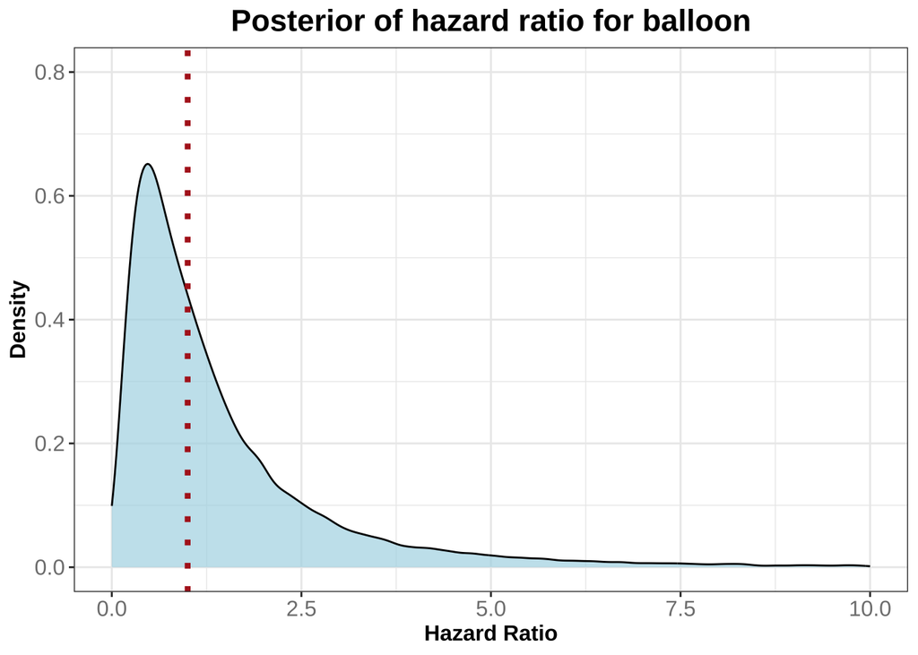

```r
ggplot(data.frame(balloon_hr), aes(x = balloon_hr)) +
  geom_density(fill = "lightblue", alpha = 0.7) +
  labs(title = "Posterior of hazard ratio for balloon",
       x = "Hazard Ratio",
       y = "Density") +
  theme_bw() +
  theme_bw() +
           theme(axis.title.y = element_text(size=12, face="bold"),
               axis.title.x = element_text(size=12, face="bold"),
               title = element_text(size=14, face="bold"),
               plot.title = element_text(hjust = 0.5),
               axis.text.x = element_text(color = "grey50", size = 12),
               axis.text.y = element_text(color = "grey50",size = 12)) +
  geom_vline(xintercept = 1, linetype="dotted",
                color = "firebrick", linewidth = 1.5) +
  xlim(0, 10) +
  ylim(0, 0.8)
```

### c. Summarise hazard ratios for stent

#### i. Numbers

```r
median(stent_hr)
```

```
## [1] 1.612126
```

```r
hpdi_stent_hr <- HPDI(stent_hr, prob = c(0.89, 0.97))
hpdi_stent_hr
```

```
##      |0.97      |0.89      0.89|      0.97|
## 0.01877267 0.04984547 5.11259904 9.90905062
```

#### ii.Plot posterior distribution for hazard ratio

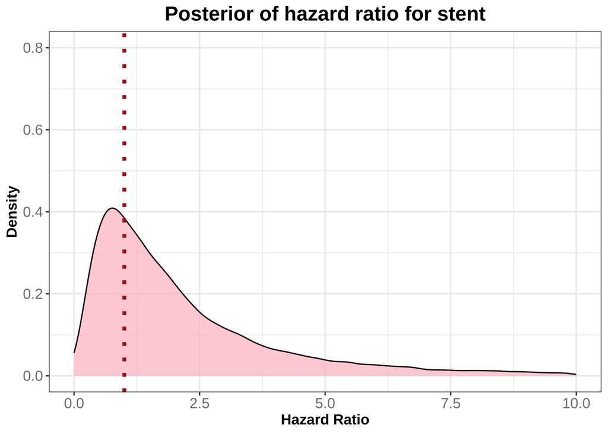

```r
ggplot(data.frame(stent_hr), aes(x = stent_hr)) +
  geom_density(fill = "pink", alpha = 0.7) +
  labs(title = "Posterior of hazard ratio for stent",
       x = "Hazard Ratio",
       y = "Density") +
  theme_bw() +
           theme(axis.title.y = element_text(size=12, face="bold"),
               axis.title.x = element_text(size=12, face="bold"),
               title = element_text(size=14, face="bold"),
               plot.title = element_text(hjust = 0.5),
               axis.text.x = element_text(color = "grey50", size = 12),
               axis.text.y = element_text(color = "grey50",size = 12)) +
  geom_vline(xintercept = 1, linetype="dotted",
                color = "firebrick", linewidth = 1.5) +
  xlim(0, 10) +
  ylim(0, 0.8)
```

### c. Summarise hazard ratios for balloon:stent

#### i. Numbers

```r
median(balloonstent_hr)
```

```
## [1] 1.552438
```

```r
hdi_balloonstent_hr <- hdi(balloonstent_hr, ci = c(0.97))
hdi_balloonstent_hr
```

```
##            [,1]     [,2]
## [1,] 0.01167866 8.175344
```

#### ii.Plot posterior distribution for hazard ratio

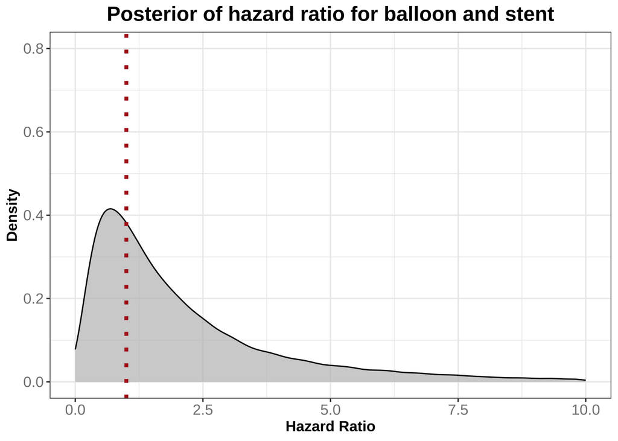

```r
ggplot(data.frame(balloonstent_hr), aes(x = balloonstent_hr)) +
  geom_density(fill = "grey", alpha = 0.7) +
  labs(title = "Posterior of hazard ratio for balloon and stent",
       x = "Hazard Ratio",
       y = "Density") +
  theme_bw() +
           theme(axis.title.y = element_text(size=12, face="bold"),
               axis.title.x = element_text(size=12, face="bold"),
               title = element_text(size=14, face="bold"),
               plot.title = element_text(hjust = 0.5),
               axis.text.x = element_text(color = "grey50", size = 12),
               axis.text.y = element_text(color = "grey50",size = 12)) +
  geom_vline(xintercept = 1, linetype="dotted",
                color = "firebrick", linewidth = 1.5) +
  xlim(0, 10) +
  ylim(0, 0.8)
```

### 2. Check performance of prior probability

```r
mod_prtyp_prior_only <- update(mod_prtyp, prior_PD = TRUE)
```

[output not shown]

```
## Also defined by 'rstan'
```

[output not shown]

```
## Also defined by 'rstan'
```

[output not shown]

```
## Also defined by 'rstan'
```

[output not shown]

```
## Also defined by 'rstan'
```

[output not shown]

```
## Also defined by 'rstan'
```

### 3. Check prosterior vs prior for beta variable

#### a. extract draws for posterior and prior

```r
# extract draws
post_draws  <- as.matrix(mod_prtyp)
prior_draws <- as.matrix(mod_prtyp_prior_only)
```

#### b. Balloon

##### i. plot marginal distributions for posterior and prior

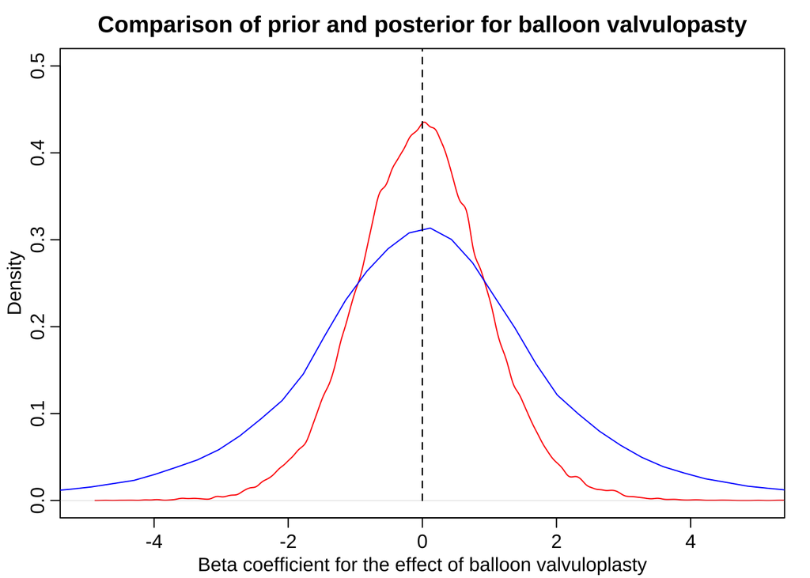

```r
# Compare marginal distributions
dens(post_draws[, "balloon"], show.zero = TRUE, col = "red", main = "Comparison of prior and posterior for balloon valvulopasty", xlab = "Beta coefficient for the effect of balloon valvuloplasty", xlim = c(-5, 5), ylim = c(0, 0.5))
dens(prior_draws[, "balloon"], add=TRUE, col = "blue", show.zero = TRUE)
```

##### ii. compute prior tail probability of posterior mean

If this probability is very small (e.g. < 0.05), the posterior lies in a region the prior considered implausible.

```r
beta_hat <- mean(post_draws[, "balloon"])

mean(abs(prior_draws[, "balloon"] - beta_hat) <
       abs(prior_draws[, "balloon"] - mean(prior_draws[, "balloon"])))
```

```
## [1] 0.4980312
```

#### c. Stent

##### i. plot marginal distributions for posterior and prior

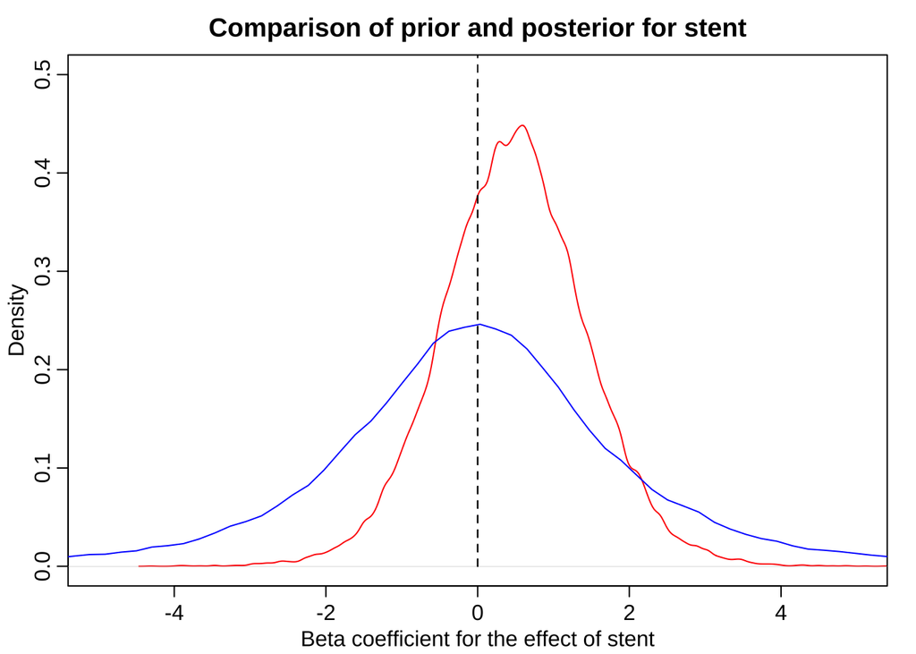

```r
# Compare marginal distributions
dens(post_draws[, "stent"], show.zero = TRUE, col = "red", main = "Comparison of prior and posterior for stent", xlab = "Beta coefficient for the effect of stent", xlim = c(-5, 5), ylim = c(0, 0.5))
dens(prior_draws[, "stent"], add=TRUE, col = "blue", show.zero = TRUE)
```

##### ii. compute prior tail probability of posterior mean

If this probability is very small (e.g. < 0.05), the posterior lies in a region the prior considered implausible.

```r
beta_hat <- mean(post_draws[, "stent"])

mean(abs(prior_draws[, "stent"] - beta_hat) <
       abs(prior_draws[, "stent"] - mean(prior_draws[, "stent"])))
```

```
## [1] 0.441125
```

#### d. Balloon then stent

##### i. plot marginal distributions for posterior and prior

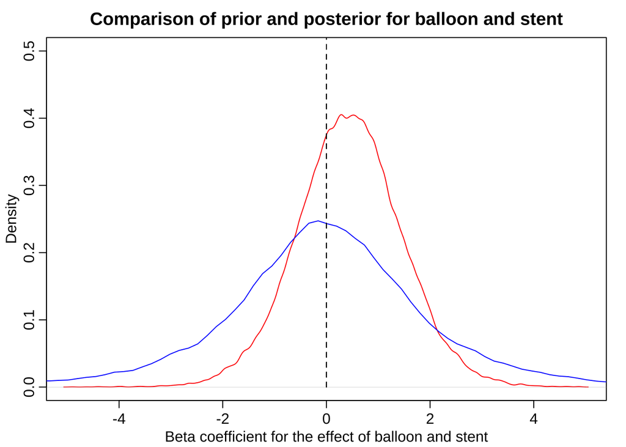

```r
# Compare marginal distributions
dens(post_draws[, "balloon:stent"], show.zero = TRUE, col = "red", main = "Comparison of prior and posterior for balloon and stent", xlab = "Beta coefficient for the effect of balloon and stent", xlim = c(-5, 5), ylim = c(0, 0.5))
dens(prior_draws[, "balloon:stent"], add=TRUE, col = "blue", show.zero = TRUE)
```

##### ii. compute prior tail probability of posterior mean

If this probability is very small (e.g. < 0.05), the posterior lies in a region the prior considered implausible.

```r
beta_hat <- mean(post_draws[, "balloon:stent"])

mean(abs(prior_draws[, "balloon:stent"] - beta_hat) <
       abs(prior_draws[, "balloon:stent"] - mean(prior_draws[, "balloon:stent"])))
```

```
## [1] 0.4437813
```

### 4. Sensitivity analyses to assess robustness of results to choice of prior

To determine whether the substantive conclusions depend upon the exact prior choice.

```r
priors_bin <- list(
  weak = student_t(df = 3, location = 0, scale = 3, autoscale = FALSE),
  moderate = student_t(df = 3, location = 0, scale = 1.5, autoscale = FALSE),
  strong = student_t(df = 3, location = 0, scale = 0.75, autoscale = FALSE)
)
```

#### b. refit model with different priors and compare results

```r
fits <- lapply(priors_bin, function(p) {
  stan_surv(formula = Surv(tstart, tstop, status) ~ balloon * stent
                        + concurrent_congenital
                        + type
                        + (1| centre),
            basehaz = "ms",
            data = df_surg,
            prior_intercept = normal(location = 0, scale = 20, autoscale = FALSE),
            prior = p,
            prior_covariance =  decov(regularization = 2, concentration = 1, shape = 1, scale = 1),
            iter    = 2000,
            chains = 4,
            cores = 4,
            adapt_delta = 0.99999,  # Often helpful for complex models
            control = list(max_treedepth = 20),
            init = 0.1,
            seed = 666
            )
})
```

[output not shown]

```
## Also defined by 'rstan'
```

[output not shown]

```
## Also defined by 'rstan'
```

[output not shown]

```
## Also defined by 'rstan'
```

[output not shown]

```
## Also defined by 'rstan'
```

[output not shown]

```
## Also defined by 'rstan'
```

[output not shown]

[output not shown]

[output not shown]

```
## Also defined by 'rstan'
```

[output not shown]

```
## Also defined by 'rstan'
```

[output not shown]

```
## Also defined by 'rstan'
```

[output not shown]

```
## Also defined by 'rstan'
```

[output not shown]

```
## Also defined by 'rstan'
```

[output not shown]

```
## Also defined by 'rstan'
```

[output not shown]

```
## Also defined by 'rstan'
```

[output not shown]

```
## Also defined by 'rstan'
```

[output not shown]

```
## Also defined by 'rstan'
```

#### c. compare posterior intervals for hazard ratios cross different priors

##### i. balloon

```r
# calculate median hazard ratio across different priors
HR_med_sens <- sapply(fits, function(f) {
  posterior::as_draws_df(f) |>
    as.data.frame() |>
    summarise(
      median = exp(quantile(balloon, probs = 0.5))
    )
})
HR_med <- c(HR_med_sens[[1]], HR_med_sens[[2]], HR_med_sens[[3]])


# calculate 89% credible interval for hazard ratio across different priors
HR_sens <- sapply(fits, function(f) {
  exp(posterior_interval(f, pars = "balloon", prob = 0.89))
})

# combine median and credible intervals into a summary table
HR_sens_summary <- rbind(HR_med, HR_sens)
row.names(HR_sens_summary) <- c("Median", "Lower", "Upper")

# transpose the table for better readability
HR_sens_summary
```

```
##              weak  moderate    strong
## Median  0.9234677 1.0158566 0.9806422
## Lower   0.0498733 0.2134275 0.4136058
## Upper  15.8037721 4.4788267 2.4012384
```

##### ii. stent

```r
# calculate median hazard ratio across different priors
HR_med_sens <- sapply(fits, function(f) {
  posterior::as_draws_df(f) |>
    as.data.frame() |>
    summarise(
      median = exp(quantile(stent, probs = 0.5))
    )
})
HR_med <- c(HR_med_sens[[1]], HR_med_sens[[2]], HR_med_sens[[3]])


# calculate 89% credible interval for hazard ratio across different priors
HR_sens <- sapply(fits, function(f) {
  exp(posterior_interval(f, pars = "stent", prob = 0.89))
})

# combine median and credible intervals into a summary table
HR_sens_summary <- rbind(HR_med, HR_sens)
row.names(HR_sens_summary) <- c("Median", "Lower", "Upper")

# transpose the table for better readability
HR_sens_summary
```

```
##               weak  moderate    strong
## Median  1.51315581 1.6113383 1.4703700
## Lower   0.08516929 0.3469655 0.6186074
## Upper  25.31450923 7.6828574 3.6817654
```

##### iii. balloon:stent

```r
# calculate median hazard ratio across different priors
HR_sens <- sapply(fits, function(f) {
  exp(posterior_interval(f, pars = "balloon:stent", prob = 0.89))
})

# combine median and credible intervals into a summary table
row.names(HR_sens) <- c("Lower", "Upper")

# transpose the table for better readability
HR_sens
```

```
##              weak  moderate    strong
## Lower  0.09655563 0.3058642 0.5386482
## Upper 34.31934296 7.8894880 4.1262800
```

## Make model predictions and plot for model_prtyp

### 1. Create new data where proc_type differs

```r
nd <- data.frame(centre = rep("p", 3),
                 balloon = c(1, 0, 1),
                 stent = c(0, 1, 1),
                 concurrent_congenital = rep(0, 3),
                 type = rep("a", 3)
                 )
head(nd)
```

```
##   centre balloon stent concurrent_congenital type
## 1      p       1     0                     0    a
## 2      p       0     1                     0    a
## 3      p       1     1                     0    a
```

### 2. Make posterior predictions from new data

```r
ps <- posterior_survfit(mod_prtyp,
  newdata = nd,
  times = 0,
  extrapolate = TRUE) |>
  suppressWarnings()
head(ps)
```

```
## stan_surv predictions
##  num. individuals: 3
##  prediction type:  event free probability
##  standardised?:    no
##  conditional?:     no
##
##   id cond_time     time median  ci_lb  ci_ub
## 1  1        NA   0.0000 1.0000 1.0000 1.0000
## 2  1        NA  32.7172 0.9854 0.9404 0.9979
## 3  1        NA  65.4343 0.9726 0.8966 0.9952
## 4  1        NA  98.1515 0.9621 0.8677 0.9925
## 5  1        NA 130.8687 0.9520 0.8493 0.9898
## 6  1        NA 163.5859 0.9436 0.8311 0.9873
```

### 3. Plot

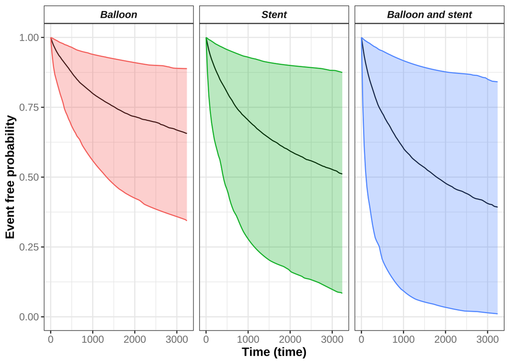

```r
panel_labels <- c('1' = "Balloon", '2' = "Stent", '3' = "Balloon and stent")
pps <- plot(ps) +
  aes(colour = factor(id), fill = factor(id)) +
  theme(legend.position = "none") +
  facet_wrap(~ id, labeller = labeller(id = panel_labels)) +
           theme(axis.title.y = element_text(size=12, face="bold"),
               axis.title.x = element_text(size=12, face="bold"),
               title = element_text(size=12, face="bold"),
               plot.title = element_text(hjust = 0.5),
               axis.text.x = element_text(color = "grey50", size = 10),
               axis.text.y = element_text(color = "grey50",size = 10)) +
            theme(strip.text.x = element_text(size = 10, face = "bold.italic"),
                   strip.background = element_rect(fill="white")
        )

print(pps)
```

## Check PH assumption visually

### make predictions of both the hazard and log hazard

```r
ph <- suppressWarnings( posterior_survfit(mod_prtyp, newdata = nd, type = "haz") )
pl <- suppressWarnings( posterior_survfit(mod_prtyp, newdata = nd, type = "loghaz") )
```

#### create plots

```r
pph <- plot(ph) +
  coord_cartesian(ylim = c(0.0, 0.005)) +
  facet_wrap(~ id, labeller = labeller(id = panel_labels))
```

```
## ℹ Adding new coordinate system, which will replace the existing one.
```

```r
ppl <- plot(pl) +
  facet_wrap(~ id, labeller = labeller(id = panel_labels))
```

#### combine plots in grid and plot

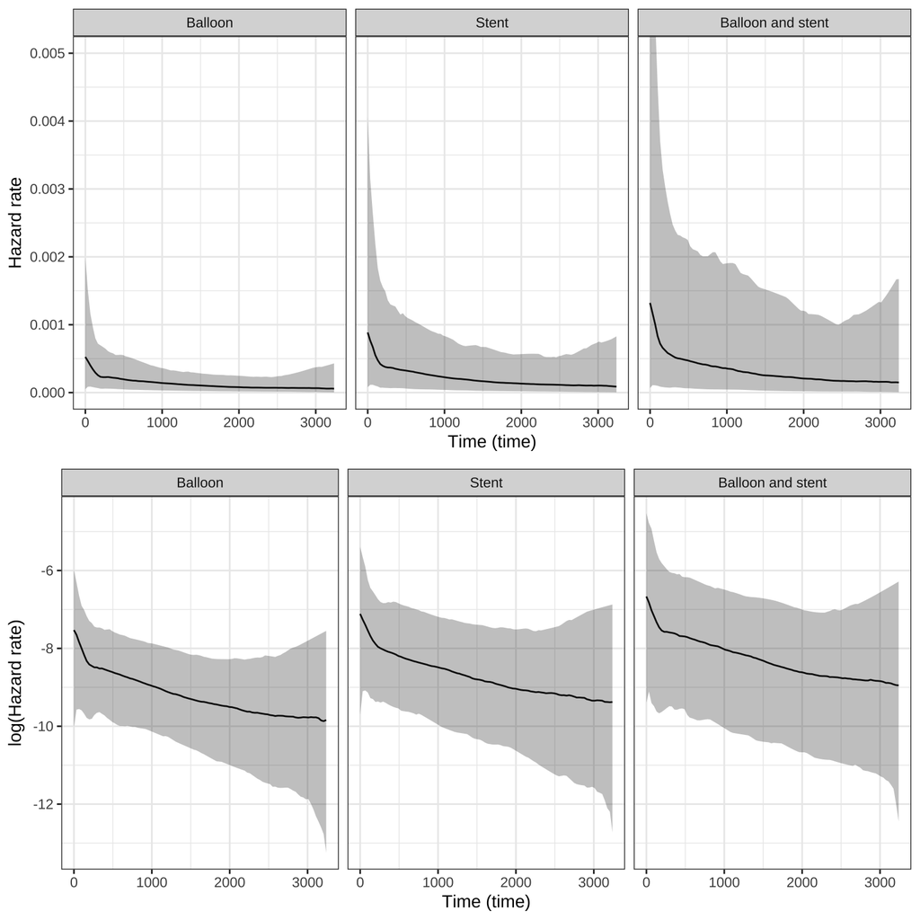

```r
plot_grid(pph, ppl, ncol = 1)
```

# XIV. Bayesian multi-level survival analysis for effect of COMPLICATIONS with random intercept for centre and control set

## Set prior for beta variables

**Set a neutral, weakly-regularising prior…**

student_t(df = 3, location = 0, scale = 2.0)

```r
prior_beta_comp <- student_t(df = 3, location = 0, scale = 2.0, autoscale = FALSE)
```

Based on the DAG, use the following adjustment variables: high pressure, low pressure, referral centre, stent. NB need to include balloon type here as well for an appropriate adjustment set

## Need to create separate variables for high pressure and low pressure so as to model complications appropriately

```r
df_surg$high_pressure <- ifelse(df_surg$balloon_type == "high_pressure", 1, 0)
df_surg$high_pressure[is.na(df_surg$high_pressure)] <- 0
df_surg$low_pressure <- ifelse(df_surg$balloon_type == "low_pressure", 1, 0)
df_surg$low_pressure[is.na(df_surg$low_pressure)] <- 0
```

## Fit model

NB use status … rstanarm requires the dead animals to be classified as 1, whilst censored are 0.

```r
mod_comp <- stan_surv(formula = Surv(tstart, tstop, status) ~ complications
                      + stent
                      + high_pressure
                      + low_pressure
                      + (1| centre),
  data = df_surg,
  basehaz = "ms",
  prior_intercept = normal(location = 0, scale = 20, autoscale = FALSE),
  prior = prior_beta_comp,
  prior_covariance =  decov(regularization = 2, concentration = 1, shape = 1, scale = 1),
  iter    = 12000,
  warmup = 4000,
  chains = 4,
  cores = 4,
  adapt_delta = 0.9999,  # Often helpful for complex models
  seed = 666)
```

[output not shown]

```
## Also defined by 'rstan'
```

[output not shown]

```
## Also defined by 'rstan'
```

[output not shown]

```
## Also defined by 'rstan'
```

[output not shown]

```
## Also defined by 'rstan'
```

[output not shown]

```
## Also defined by 'rstan'
```

## Summarise priors from model

```r
prior_summary(mod_comp)
```

```
## Priors for model 'mod_comp'
## ------
## Intercept
##  ~ normal(location = 0, scale = 20)
##
## Coefficients
##  ~ student_t(df = [3,3,3,...], location = [0,0,0,...], scale = [2,2,2,...])
##
## Auxiliary (M-spline-coefficients)
##  ~ dirichlet(concentration = [1,1,1,...])
##
## Covariance
##  ~ decov(reg. = 2, conc. = 1, shape = 1, scale = 1)
## ------
## See help('prior_summary.stanreg') for more details
```

## Model summary

```r
summary(mod_comp)
```

```
##
## Model Info:
##
##  function:        stan_surv
##  baseline hazard: M-splines on hazard scale
##  formula:         Surv(tstart, tstop, status) ~ complications + stent + high_pressure +
##     low_pressure + (1 | centre)
##  algorithm:       sampling
##  sample:          32000 (posterior sample size)
##  priors:          see help('prior_summary')
##  observations:    85
##  events:          25 (29.4%)
##  right censored:  60 (70.6%)
##  delayed entry:   yes
##
## Estimates:
##                                         mean   sd   10%   50%   90%
## (Intercept)                           -2.9    1.3 -4.6  -2.9  -1.3
## complications1                         1.2    0.5  0.6   1.2   1.8
## stent                                  2.4    1.1  0.9   2.4   3.8
## high_pressure                          1.4    1.1  0.1   1.5   2.8
## low_pressure                           2.7    1.2  1.2   2.7   4.2
## m-splines-coef1                        0.1    0.1  0.0   0.1   0.2
## m-splines-coef2                        0.1    0.1  0.0   0.1   0.2
## m-splines-coef3                        0.4    0.2  0.2   0.4   0.6
## m-splines-coef4                        0.2    0.1  0.0   0.1   0.4
## m-splines-coef5                        0.1    0.1  0.0   0.1   0.2
## m-splines-coef6                        0.1    0.1  0.0   0.1   0.3
## b[(Intercept) centre:p]               -0.4    0.7 -1.2  -0.2   0.3
## b[(Intercept) centre:sath]            -0.1    0.6 -0.9  -0.1   0.5
## b[(Intercept) centre:willows]          0.5    0.7 -0.1   0.4   1.4
## Sigma[centre:(Intercept),(Intercept)]  1.0    1.8  0.0   0.4   2.3
##
## MCMC diagnostics
##                                       mcse Rhat n_eff
## (Intercept)                           0.0  1.0  10828
## complications1                        0.0  1.0  24742
## stent                                 0.0  1.0  11390
## high_pressure                         0.0  1.0  11525
## low_pressure                          0.0  1.0  11459
## m-splines-coef1                       0.0  1.0  40627
## m-splines-coef2                       0.0  1.0  31144
## m-splines-coef3                       0.0  1.0  30181
## m-splines-coef4                       0.0  1.0  27130
## m-splines-coef5                       0.0  1.0  38831
## m-splines-coef6                       0.0  1.0  39829
## b[(Intercept) centre:p]               0.0  1.0  14569
## b[(Intercept) centre:sath]            0.0  1.0  12049
## b[(Intercept) centre:willows]         0.0  1.0  10498
## Sigma[centre:(Intercept),(Intercept)] 0.0  1.0  17016
## log-posterior                         0.0  1.0   9433
##
## For each parameter, mcse is Monte Carlo standard error, n_eff is a crude measure of effective sample size, and Rhat is the potential scale reduction factor on split chains (at convergence Rhat=1).
```

## Model short summary

```r
print(mod_comp, digits = 3)
```

```
## stan_surv
##  baseline hazard: M-splines on hazard scale
##  formula:         Surv(tstart, tstop, status) ~ complications + stent + high_pressure +
##     low_pressure + (1 | centre)
##  observations:    85
##  events:          25 (29.4%)
##  right censored:  60 (70.6%)
##  delayed entry:   yes
## ------
##                 Median MAD_SD exp(Median)
## (Intercept)     -2.898  1.291     NA
## complications1   1.197  0.459  3.310
## stent            2.378  1.127 10.784
## high_pressure    1.466  1.087  4.333
## low_pressure     2.682  1.183 14.608
## m-splines-coef1  0.083  0.054     NA
## m-splines-coef2  0.084  0.064     NA
## m-splines-coef3  0.430  0.159     NA
## m-splines-coef4  0.132  0.125     NA
## m-splines-coef5  0.076  0.076     NA
## m-splines-coef6  0.090  0.090     NA
##
## Error terms:
##  Groups Name        Std.Dev.
##  centre (Intercept) 0.9801
## Num. levels: centre 3
##
## ------
## * For help interpreting the printed output see ?print.stanreg
## * For info on the priors used see ?prior_summary.stanreg
```

## Plot Baseline hazard of model

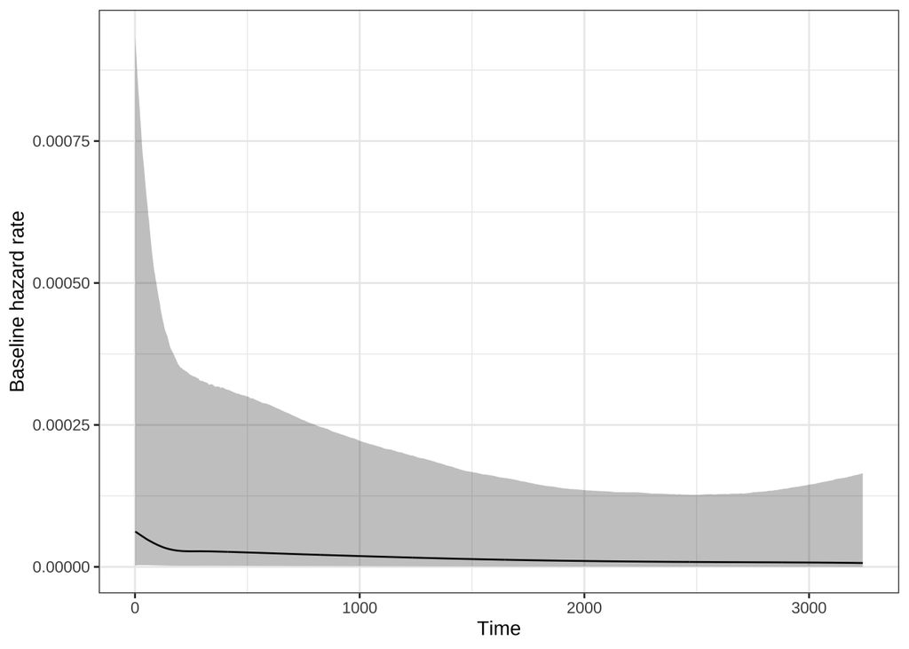

```r
plot(mod_comp)
```

## Plots of model convergences

## Get results

```r
posterior_mod_comp <- as.array(mod_comp)
```

### a. Check trace plots for model

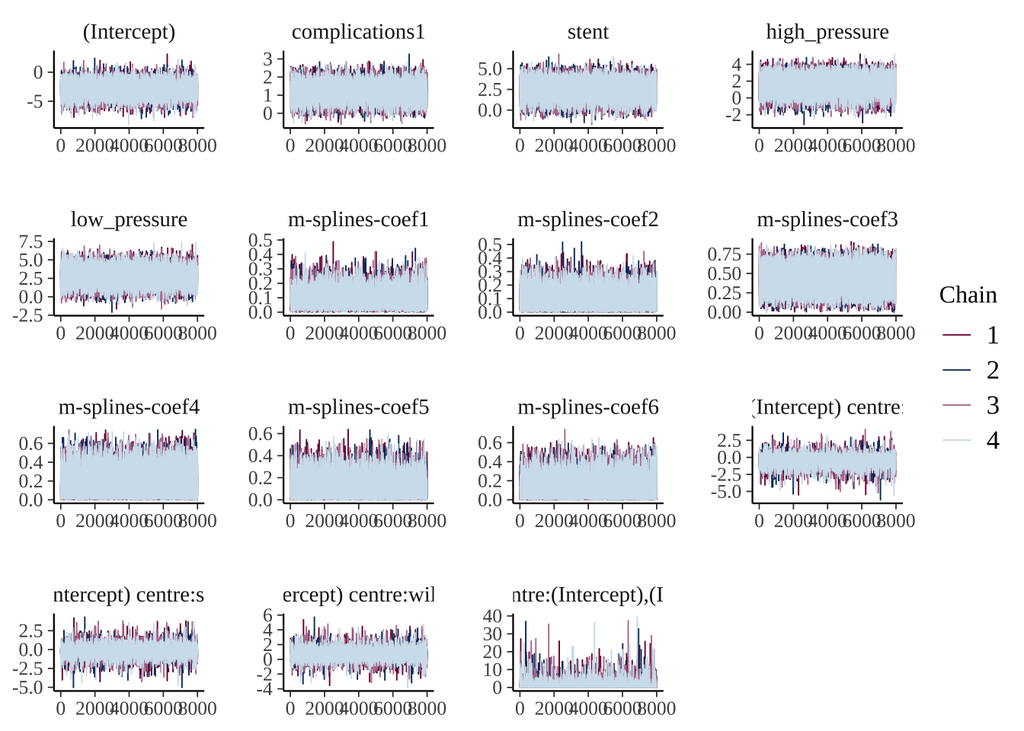

```r
color_scheme_set("mix-blue-pink")
mcmc_trace(posterior_mod_comp)
```

### b. Trace rank plot

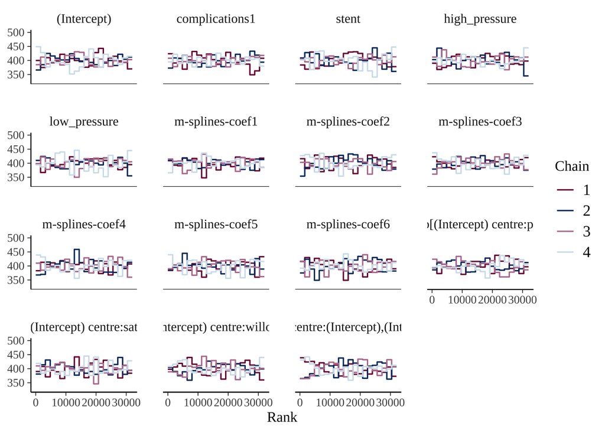

```r
color_scheme_set("mix-blue-pink")
mcmc_rank_overlay(posterior_mod_comp) +
  ylim(325, 500)
```

### c. get dens overlay plot for chains

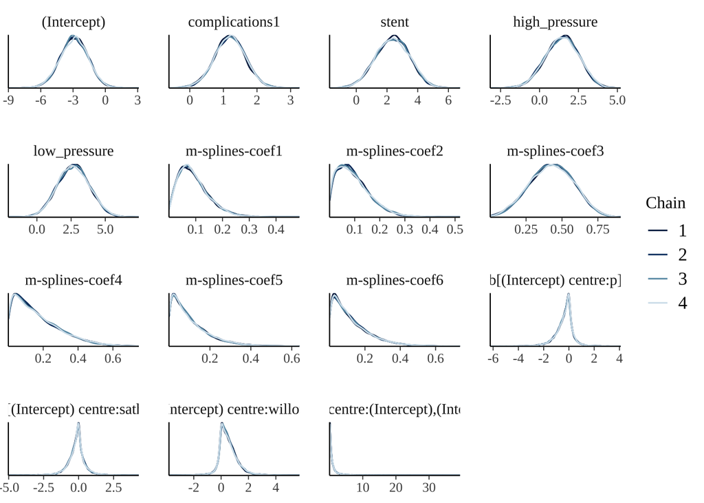

```r
color_scheme_set("blue")
mcmc_dens_overlay(posterior_mod_comp)
```

## Summaries of coefficients

### a. HPDI for the different beta parameters

```r
draws <- as.matrix(mod_comp)
median(draws[,2]) #draws for complications
```

```
## [1] 1.197012
```

```r
HPDI(draws[,2], 0.97) # draws for complications
```

```
##     |0.97     0.97|
## 0.1797935 2.1931101
```

```r
HPDI(draws[,2], 0.89) # draws for complications
```

```
##     |0.89     0.89|
## 0.4554693 1.9347103
```

### b. Hypothesis tests on beta parameters

#### complications

probability that effect is positive

```r
mean(draws[,2] > 0) # draws for complications
```

```
## [1] 0.994125
```

### c. Plot posterior distribution for beta coefficient of complications

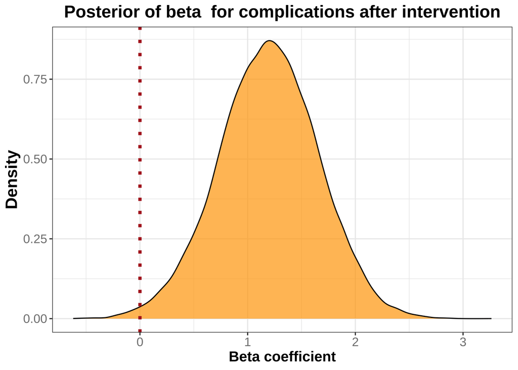

```r
aten_comp <- draws[,2] # 2nd column is draws for complications

ggplot(data.frame(aten_comp), aes(x = aten_comp)) +
  geom_density(fill = "orange", alpha = 0.7) +
  labs(title = "Posterior of beta  for complications after intervention",
       x = "Beta coefficient",
       y = "Density") +
  theme_bw() +
           theme(axis.title.y = element_text(size=16, face="bold"),
               axis.title.x = element_text(size=14, face="bold"),
               title = element_text(size=14, face="bold"),
               plot.title = element_text(hjust = 0.5),
               axis.text.x = element_text(color = "grey50", size = 12),
               axis.text.y = element_text(color = "grey50",size = 12)) +
  geom_vline(xintercept = 0, linetype="dotted",
                color = "firebrick", linewidth = 1.5)
```

## Get HDI for coefficients

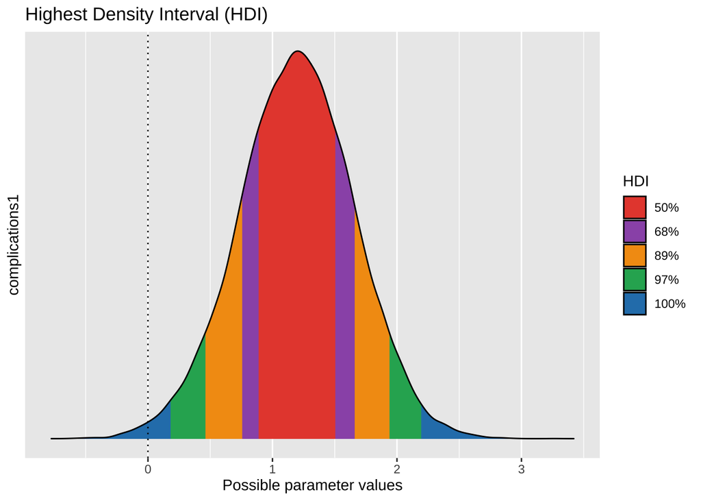

```r
hdi <- bayestestR::hdi(mod_comp, ci = c(0.50, 0.68, 0.89, 0.97), parameters = "complications")
plot(hdi)
```

## Get density plots for posterior distributons of beta parameters

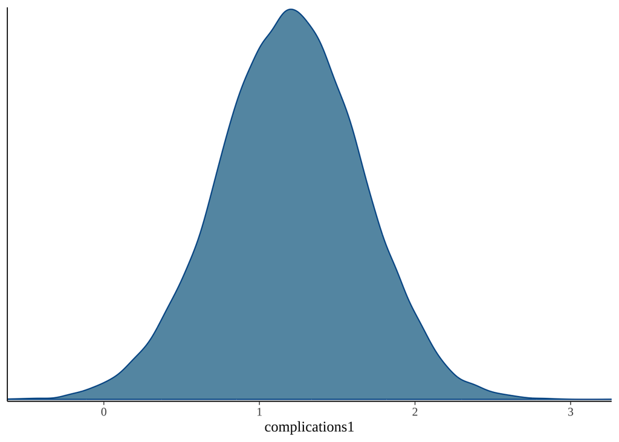

```r
mcmc_dens(posterior_mod_comp,
  pars = c("complications1"))
```

## Get area plot for posterior distributons of beta parameters

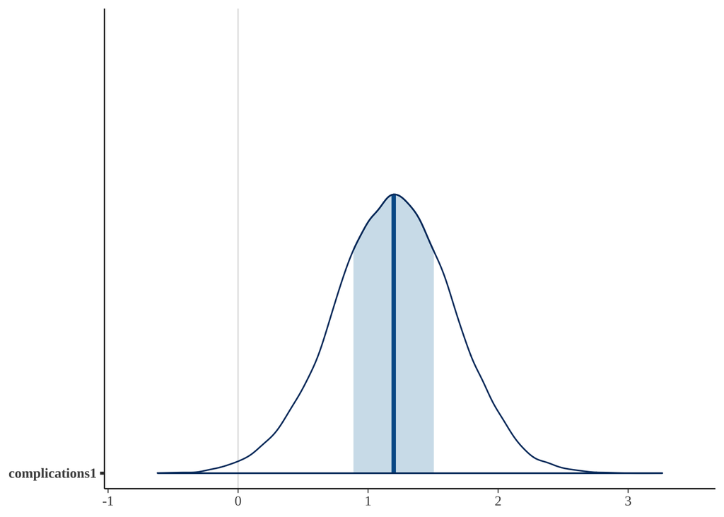

```r
mcmc_areas(posterior_mod_comp,
  pars = "complications1")
```

## Calculate hazard ratios for complications

### a. get posterior draws

```r
comp_hr <- exp(draws[,2]) # draws for complications
```

### b. Summarise hazard ratios for complications

```r
median(comp_hr)
```

```
## [1] 3.310212
```

```r
hpdi_comp <- HPDI(comp_hr, prob = c(0.89, 0.97))
hpdi_comp
```

```
##     |0.97     |0.89     0.89|     0.97|
## 0.8608961 1.1323340 5.9628681 7.8871681
```

### c. Plot posterior distribution for hazard ratio of comp_hr

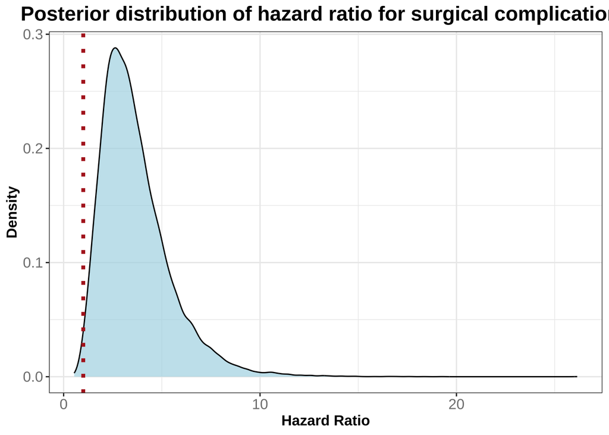

```r
ggplot(data.frame(comp_hr), aes(x = comp_hr)) +
  geom_density(fill = "lightblue", alpha = 0.7) +
  labs(title = "Posterior distribution of hazard ratio for surgical complications",
       x = "Hazard Ratio",
       y = "Density") +
  theme_bw() +
           theme(axis.title.y = element_text(size=12, face="bold"),
               axis.title.x = element_text(size=12, face="bold"),
               title = element_text(size=14, face="bold"),
               plot.title = element_text(hjust = 0.5),
               axis.text.x = element_text(color = "grey50", size = 12),
               axis.text.y = element_text(color = "grey50",size = 12)) +
  geom_vline(xintercept = 1, linetype="dotted",
                color = "firebrick", linewidth = 1.5)
```

### 2. Check performance of prior probability

```r
mod_comp_prior_only <- update(mod_comp, prior_PD = TRUE)
```

[output not shown]

```
## Also defined by 'rstan'
```

[output not shown]

```
## Also defined by 'rstan'
```

[output not shown]

```
## Also defined by 'rstan'
```

[output not shown]

```
## Also defined by 'rstan'
```

[output not shown]

```
## Also defined by 'rstan'
```

### 3. Check prosterior vs prior for beta variable

#### a. extract draws for posterior and prior

```r
# extract draws
post_draws  <- as.matrix(mod_comp)
prior_draws <- as.matrix(mod_comp_prior_only)
```

#### b. plot marginal distributions for posterior and prior

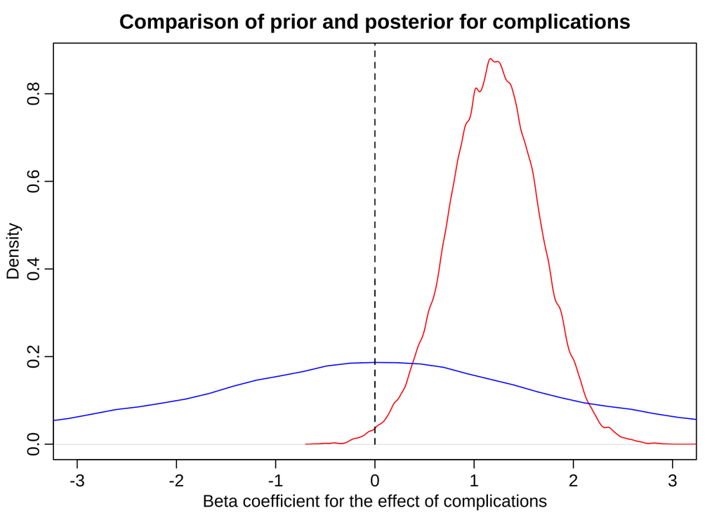

```r
# Compare marginal distributions
dens(post_draws[, "complications1"], show.zero = TRUE, col = "red", main = "Comparison of prior and posterior for complications", xlab = "Beta coefficient for the effect of complications", xlim = c(-3, 3))
dens(prior_draws[, "complications1"], add=TRUE, col = "blue", show.zero = TRUE)
```

#### c. compute prior tail probability of posterior mean

If this probability is very small (e.g. < 0.05), the posterior lies in a region the prior considered implausible.

```r
beta_hat <- mean(post_draws[, "complications1"])

mean(abs(prior_draws[, "complications1"] - beta_hat) <
       abs(prior_draws[, "complications1"] - mean(prior_draws[, "complications1"])))
```

```
## [1] 0.3910312
```